# topic-modeling-finding-related-articles

## Did you find an interesting article and want to easily find related research without browsing all existing publications yourself? Do you have a specific research question and want to discover relevant articles? Then this notebook might help you.

**Approach**: We first discover a number of topics using LDA (Latent Dirichlet Allocation). This allows us to view each article as a mixture of these topics. By mapping a specific article into the topic space (a simplex with a topic in each corner), we can then find related articles.

**Quickstart possible**: You don't have to train the model yourself, you can simply load it from the output files!

### Coming soon: Website

Because of all the positive feedback and the growing interest in this recommendation system, we will soon host it as a web service to make it more accessible to the broader public!

### User-friendly version available: [User-Friendly: Finding Related Articles](https://www.kaggle.com/danielwolffram/user-friendly-finding-related-articles).

If you are not interested in the implementation and just want to use the widgets to discover relevant articles, then this is for you!

**Features**

- Similarity measure to show the **confidence** in the recommendations
- Plots that show the **topic-distribution** of an article
- Select a **time range** to limit the articles that are considered (you can decide if you want to find the latest publications or search for insights in past research)
- Option to only suggest **COVID-19-papers** (those that contain COVID-19, SARS-CoV-2, 2019-nCov, SARS Coronavirus 2 or 2019 Novel Coronavirus in the text body)

**Pros**:

- Doesn't only use the title or meta-data, but the actual content (text body) of the articles
- Once trained, the model is easy and fast to apply
- Helps to discover latent relationships between articles that might drive innovation

**Cons**:

- Unsupervised learning of topics is hard to verify

Any feedback and ideas for the open problems are welcome!

[figure not shown]

*Topic = Distribution over Words*

*Document = Mixture of Topics*

Reference: https://www.youtube.com/watch?v=3mHy4OSyRf0&t=515s

# Install/Load Packages

*Internet access needs to be switched on for this to work!*

```python
from IPython.utils import io
with io.capture_output() as captured:
    !pip install scispacy
    !pip install https://s3-us-west-2.amazonaws.com/ai2-s2-scispacy/releases/v0.2.4/en_core_sci_md-0.2.4.tar.gz
```

```python
import numpy as np
import pandas as pd

from sklearn.feature_extraction import text
from sklearn.feature_extraction.text import CountVectorizer, TfidfVectorizer
from sklearn.decomposition import LatentDirichletAllocation

import scispacy
import spacy
import en_core_sci_md

from scipy.spatial.distance import jensenshannon

import joblib

from IPython.display import HTML, display

from ipywidgets import interact, Layout, HBox, VBox, Box
import ipywidgets as widgets
from IPython.display import clear_output

from tqdm import tqdm
from os.path import isfile

import seaborn as sb
import matplotlib.pyplot as plt
plt.style.use("dark_background")
```

# Load and Prepare Data

```python
df = pd.read_csv('output/cord19_df.csv')
```

```python
df.head()
```

|  | paper_id | body_text | source_x | title | doi | pmcid | pubmed_id | license | abstract | publish_time | authors | journal | Microsoft Academic Paper ID | WHO #Covidence | has_full_text | full_text_file | publish_year | url | text_language |
| --- | --- | --- | --- | --- | --- | --- | --- | --- | --- | --- | --- | --- | --- | --- | --- | --- | --- | --- | --- |
| 0 | 0015023cc06b5362d332b3baf348d11567ca2fbb | VP3, and VP0 (which is further processed to VP... | biorxiv | The RNA pseudoknots in foot-and-mouth disease ... | 10.1101/2020.01.10.901801 | NaN | NaN | biorxiv | The positive stranded RNA genomes of picornavi... | 2020-01-11 | Ward, J. C. J.; Lasecka-Dykes, L.; Neil, C.; A... | NaN | NaN | NaN | True | biorxiv_medrxiv | 2020 | http://dx.doi.org/10.1101/2020.01.10.901801 | en |
| 1 | 004f0f8bb66cf446678dc13cf2701feec4f36d76 | The 2019-nCoV epidemic has spread across China... | medrxiv | Healthcare-resource-adjusted vulnerabilities t... | 10.1101/2020.02.11.20022111 | NaN | NaN | medrvix | We integrate the human movement and healthcare... | 2020-02-12 | Hanchu Zhou; Jianan Yang; Kaichen Tang; Qingpe... | NaN | NaN | NaN | True | biorxiv_medrxiv | 2020 | http://dx.doi.org/10.1101/2020.02.11.20022111 | en |
| 2 | 00d16927588fb04d4be0e6b269fc02f0d3c2aa7b | Infectious bronchitis (IB), which is caused by... | biorxiv | Real-time, MinION-based, amplicon sequencing f... | 10.1101/634600 | NaN | NaN | biorxiv | Infectious bronchitis (IB) causes significant ... | 2019-05-10 | Butt, S. L.; Erwood, E. C.; Zhang, J.; Sellers... | NaN | NaN | NaN | True | biorxiv_medrxiv | 2019 | http://dx.doi.org/10.1101/634600 | en |
| 3 | 0139ea4ca580af99b602c6435368e7fdbefacb03 | Nipah is an infectious negative-sense single-s... | biorxiv | A Combined Evidence Approach to Prioritize Nip... | 10.1101/2020.03.12.977918 | NaN | NaN | biorxiv | AbstractBackgroundNipah Virus (NiV) came into ... | 2020-03-12 | Nishi Kumari; Ayush Upadhyay; Kishan Kalia; Ra... | NaN | NaN | NaN | True | biorxiv_medrxiv | 2020 | http://dx.doi.org/10.1101/2020.03.12.977918 | en |
| 4 | 013d9d1cba8a54d5d3718c229b812d7cf91b6c89 | In December 2019, a cluster of patients with p... | medrxiv | Assessing spread risk of Wuhan novel coronavir... | 10.1101/2020.02.04.20020479 | NaN | NaN | medrvix | Background: A novel coronavirus (2019-nCoV) em... | 2020-02-05 | Shengjie Lai; Isaac Bogoch; Nick Ruktanonchai;... | NaN | NaN | NaN | True | biorxiv_medrxiv | 2020 | http://dx.doi.org/10.1101/2020.02.04.20020479 | en |

```python
df.shape
```

```
(28567, 19)
```

We consider the text body, but the approach could also be applied to the abstracts only.

```python
all_texts = df.body_text
```

```python
# example snippet
all_texts[0][:10000]
```

```
'VP3, and VP0 (which is further processed to VP2 and VP4 during virus assembly) (6). The P2 64 and P3 regions encode the non-structural proteins 2B and 2C and 3A, 3B (1-3) (VPg), 3C pro and 4 structural protein-coding region is replaced by reporter genes, allow the study of genome 68 replication wit…
```

# Latend Dirichlet Allocation

For preprocessing we use [scispaCy](https://allenai.github.io/scispacy/), which is a Python package containing [spaCy](https://spacy.io) models for processing biomedical, scientific or clinical text.

```python
# medium model
nlp = en_core_sci_md.load(disable=["tagger", "parser", "ner"])
nlp.max_length = 2000000
```

```python
def spacy_tokenizer(sentence):
    return [word.lemma_ for word in nlp(sentence) if not (word.like_num or word.is_stop or word.is_punct or word.is_space or len(word)==1)]
```

```python
# New stop words list
customize_stop_words = [
    'doi', 'preprint', 'copyright', 'peer', 'reviewed', 'org', 'https', 'et', 'al', 'author', 'figure',
    'rights', 'reserved', 'permission', 'used', 'using', 'biorxiv', 'fig', 'fig.', 'al.',
    'di', 'la', 'il', 'del', 'le', 'della', 'dei', 'delle', 'una', 'da',  'dell',  'non', 'si'
]

# Mark them as stop words
for w in customize_stop_words:
    nlp.vocab[w].is_stop = True
```

```python
filepath = 'output/'
```

Generate files/models if they are not there yet.

```python
vectorizer = CountVectorizer(tokenizer = spacy_tokenizer, max_features=800000)
data_vectorized = vectorizer.fit_transform(tqdm(all_texts))

joblib.dump(vectorizer, 'vectorizer.csv')
joblib.dump(data_vectorized, 'data_vectorized.csv')
```

```
['data_vectorized.csv']
```

```python
# if not (isfile(filepath + 'vectorizer.csv') & isfile(filepath + 'data_vectorized.csv')):
#     print('Files not there: generating')
#     vectorizer = CountVectorizer(tokenizer = spacy_tokenizer, max_features=800000)
#     data_vectorized = vectorizer.fit_transform(tqdm(all_texts))
#     joblib.dump(vectorizer, 'vectorizer.csv')
#     joblib.dump(data_vectorized, 'data_vectorized.csv')

# else:
#     vectorizer = joblib.load(filepath + 'vectorizer.csv')
#     data_vectorized = joblib.load(filepath + 'data_vectorized.csv')
```

```python
data_vectorized.shape
```

```
(28567, 800000)
```

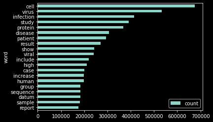

```python
# most frequent words
word_count = pd.DataFrame({'word': vectorizer.get_feature_names(), 'count': np.asarray(data_vectorized.sum(axis=0))[0]})

word_count.sort_values('count', ascending=False).set_index('word')[:20].sort_values('count', ascending=True).plot(kind='barh')
```

```python
lda = LatentDirichletAllocation(n_components=50, random_state=0)
lda.fit(data_vectorized)
joblib.dump(lda, 'lda.csv')
```

```
['lda.csv']
```

```python
lda80 = LatentDirichletAllocation(n_components=80, random_state=0)
lda80.fit(data_vectorized)
joblib.dump(lda80, 'lda80.csv')
```

```
['lda80.csv']
```

```python
# # Train/Load Model
# if not (isfile(filepath + 'lda.csv')):
#     print('File not there: generating')
#     lda = LatentDirichletAllocation(n_components=50, random_state=0)
#     lda.fit(data_vectorized)

#     joblib.dump(lda, 'lda.csv')

# else:
#     lda = joblib.load(filepath + 'lda.csv')
```

## Discovered Topics

```python
def print_top_words(model, vectorizer, n_top_words):
    feature_names = vectorizer.get_feature_names()
    for topic_idx, topic in enumerate(model.components_):
        message = "\nTopic #%d: " % topic_idx
        message += " ".join([feature_names[i]
                             for i in topic.argsort()[:-n_top_words - 1:-1]])
        print(message)
    print()
```

```python
print_top_words(lda, vectorizer, n_top_words=25)
```

```
Topic #0: model datum numb value network time method parameter rate individual set result population different distribution estimate probability give base analysis approach case dynamic size show

Topic #1: dog parasite cat canine species study sample t. infection animal spp p. positive test b. cdv l. cpv prevalence report malaria find host wild domestic

Topic #2: cat dog study blood disease serum group clinical test treatment increase concentration live day report feline include result time case high sample level plasma sign

Topic #3: water plant food process treatment bacterium product chemical pathogen environmental waste production produce material use soil high system surface wastewater virus environment organic level microorganism

Topic #4: patient study asthma treatment symptom effect group trial dose subject clinical child allergic drug day therapy result report nasal disease increase level year exacerbation show

Topic #5: infection patient bacterial disease study bacterium s. hiv include associate cmv viral recipient cause pathogen therapy chronic treatment transplant culture pneumonia clinical increase find case

Topic #6: antibody mouse cell response serum group igg antigen day neutralize vaccine titer immune challenge show high induce epitope immunization control immunize mabs mab protection animal

Topic #7: patient antibiotic treatment therapy resistance use clinical antimicrobial pneumonia isolate result drug risk infection day rate care include test increase blood culture treat case study

Topic #8: hospital patient infection care nurse control hand staff study worker room contact use healthcare transmission mask hygiene isolation hcws facility practice medical precaution risk health

Topic #9: compound activity acid drug effect inhibitor show group cell extract inhibit study inhibition concentration derivative reaction report active antiviral enzyme treatment find result ic inhibitory

Topic #10: particle nanoparticle filter bacterium size surface aerosol bacterial study material efficiency polymer microbial concentration high increase effect de microbiota diameter show silver solution nm microorganism

Topic #11: cell protein membrane virus viral replication er rna mutant mhv show infect autophagy vesicle contain infection structure golgi particle suggest result complex formation wt form

Topic #12: virus influenza human pandemic infection h1n1 ha h5n1 avian strain viral subtype study cause infect respiratory na antiviral h7n9 seasonal oseltamivir h3n2 vaccine outbreak rotavirus

Topic #13: structure bind residue protein interaction site peptide domain form complex show sequence molecule region structural surface loop pro model acid position bond base study conformation

Topic #14: rabbit pet species animal guinea diet find food small disease zealand bladder high large calcium level result cuniculus cause place owner stress increase domestic water

Topic #15: rna sequence virus primer pcr sample strain viral rt-pcr gene min detect show cdna assay study genome kit product reaction reverse isolate table perform amplify

Topic #16: gene expression analysis protein identify datum sequence study pathway sample response read table level infection transcript include genome host cell express database rna profile set

Topic #17: sequence virus genome strain gene species region viral protein isolate analysis ibv nucleotide host acid group phylogenetic amino human study recombination identify coronavirus different genetic

Topic #18: datum system information provide include laboratory use study test train health research surveillance report need participant process require program emergency medical time review clinical result

Topic #19: protease cheetah ev serine marine cleavage sea cryptosporidium peptidase species cancer cystatin mt trypsin c. human find study tmprss2 carbon identify include seal cysteine enzyme

```

[output cut: 44 more lines]

```
Topic #42: respiratory infection child virus study patient viral rsv age pneumonia year case illness symptom test clinical influenza disease infant cause pathogen include detect adult high

Topic #43: cell response immune infection mouse cytokine expression activation macrophage receptor increase induce role signal production activate inflammatory level type disease study function human cd4 cd8

Topic #44: cell virus infection viral infect expression antiviral replication ifn culture protein show activity effect line level type result assay human medium inhibit control study express

Topic #45: pig sample group virus serum cell prrsv study infection antibody test day pedv infect control positive piglet strain show high ml detect elisa culture porcine

Topic #46: stress cell group protein increase expression level activation induce pathway signal er show nf-κb study control effect significantly bone treatment phosphorylation upr result rig-i oxidative

Topic #47: mouse cell lung tissue day expression stain show level group control animal compare infection section observe study datum analysis human perform model antibody follow significantly

Topic #48: mers-cov sars case patient sars-cov infection coronavirus report respiratory outbreak mers day transmission holder author/funder peer-reviewed license human confirm contact symptom infect disease test covid-19

Topic #49: calve herd diarrhea cattle farm animal study calf milk cow rotavirus day colostrum bovine age coli dairy sample high disease e. group feed diarrhoea result
```

```python
doc_topic_dist = pd.DataFrame(lda.transform(data_vectorized))
doc_topic_dist.to_csv('doc_topic_dist.csv', index=False)
```

```python
# if not (isfile(filepath + 'doc_topic_dist.csv')):
#         print('File not there: generating')
#         doc_topic_dist = pd.DataFrame(lda.transform(data_vectorized))
#         doc_topic_dist.to_csv('doc_topic_dist.csv', index=False)
# else:
#         doc_topic_dist = pd.read_csv(filepath + 'doc_topic_dist.csv')
```

```python
doc_topic_dist.head()
```

|  | 0 | 1 | 2 | 3 | 4 | 5 | 6 | 7 | 8 | 9 | ... | 40 | 41 | 42 | 43 | 44 | 45 | 46 | 47 | 48 | 49 |
| --- | --- | --- | --- | --- | --- | --- | --- | --- | --- | --- | --- | --- | --- | --- | --- | --- | --- | --- | --- | --- | --- |
| 0 | 0.000026 | 0.000026 | 0.000026 | 0.000026 | 0.000026 | 0.000026 | 0.000026 | 0.000026 | 0.000026 | 0.000026 | ... | 0.000026 | 0.034160 | 0.000026 | 0.000026 | 0.000026 | 0.000026 | 0.000026 | 0.000026 | 0.088248 | 0.000026 |
| 1 | 0.044276 | 0.000051 | 0.000051 | 0.000051 | 0.000051 | 0.000051 | 0.000051 | 0.000051 | 0.000051 | 0.000051 | ... | 0.000051 | 0.000051 | 0.000051 | 0.000051 | 0.000051 | 0.000051 | 0.000051 | 0.000051 | 0.289099 | 0.000051 |
| 2 | 0.000010 | 0.000010 | 0.000010 | 0.000010 | 0.000010 | 0.000010 | 0.000010 | 0.000010 | 0.000010 | 0.000010 | ... | 0.000010 | 0.000010 | 0.000010 | 0.000010 | 0.000010 | 0.000010 | 0.000010 | 0.000010 | 0.050541 | 0.000010 |
| 3 | 0.144916 | 0.000016 | 0.000016 | 0.000016 | 0.000016 | 0.000016 | 0.000016 | 0.000016 | 0.000016 | 0.166164 | ... | 0.000016 | 0.000016 | 0.000016 | 0.011797 | 0.000016 | 0.000016 | 0.000016 | 0.000016 | 0.027923 | 0.000016 |
| 4 | 0.000009 | 0.000009 | 0.000009 | 0.000009 | 0.000009 | 0.000009 | 0.000009 | 0.000009 | 0.000009 | 0.000009 | ... | 0.000009 | 0.000009 | 0.000009 | 0.000009 | 0.000009 | 0.000009 | 0.000009 | 0.000009 | 0.383317 | 0.000009 |

5 rows × 50 columns

```python
# #doc_topic_dist.sort_values(48, ascending=False)

# # German
# doc_topic_dist[(doc_topic_dist[[39]]>0.7).values.flatten()].shape

# doc_topic_dist[(doc_topic_dist[[39]]>0.1).values.flatten()][[39]].hist()

# df[(doc_topic_dist[[39]]>0.5).values.flatten()]

# df[(doc_topic_dist[[39]]>0.4).values.flatten()]

# # French
# doc_topic_dist[(doc_topic_dist[[48]]>0.8).values.flatten()].shape
```

# Get Nearest Papers (in Topic Space)

```python
is_covid19_article = df.body_text.str.contains('COVID-19|SARS-CoV-2|2019-nCov|SARS Coronavirus 2|2019 Novel Coronavirus')
```

```python
def get_k_nearest_docs(doc_dist, k=5, lower=1950, upper=2020, only_covid19=False, get_dist=False):
    '''
    doc_dist: topic distribution (sums to 1) of one article

    Returns the index of the k nearest articles (as by Jensen–Shannon divergence in topic space).
    '''

    relevant_time = df.publish_year.between(lower, upper)

    if only_covid19:
        temp = doc_topic_dist[relevant_time & is_covid19_article]

    else:
        temp = doc_topic_dist[relevant_time]

    distances = temp.apply(lambda x: jensenshannon(x, doc_dist), axis=1)
    k_nearest = distances[distances != 0].nsmallest(n=k).index

    if get_dist:
        k_distances = distances[distances != 0].nsmallest(n=k)
        return k_nearest, k_distances
    else:
        return k_nearest
```

```python
# d = get_k_nearest_docs(doc_topic_dist[df.paper_id == '90b5ecf991032f3918ad43b252e17d1171b4ea63'].iloc[0])

# sb.kdeplot(d)
```

```python
def plot_article_dna(paper_id, width=20):
    t = df[df.paper_id == paper_id].title.values[0]
    doc_topic_dist[df.paper_id == paper_id].T.plot(kind='bar', legend=None, title=t, figsize=(width, 4))
    plt.xlabel('Topic')

def compare_dnas(paper_id, recommendation_id, width=20):
    t = df[df.paper_id == recommendation_id].title.values[0]
    temp = doc_topic_dist[df.paper_id == paper_id]
    ymax = temp.max(axis=1).values[0]*1.25
    temp = pd.concat([temp, doc_topic_dist[df.paper_id == recommendation_id]])
    temp.T.plot(kind='bar', title=t, figsize=(width, 4), ylim= [0, ymax])
    plt.xlabel('Topic')
    plt.legend(['Selection', 'Recommendation'])

# compare_dnas('90b5ecf991032f3918ad43b252e17d1171b4ea63', 'a137eb51461b4a4ed3980aa5b9cb2f2c1cf0292a')

def dna_tabs(paper_ids):
    k = len(paper_ids)
    outs = [widgets.Output() for i in range(k)]

    tab = widgets.Tab(children = outs)
    tab_titles = ['Paper ' + str(i+1) for i in range(k)]
    for i, t in enumerate(tab_titles):
        tab.set_title(i, t)
    display(tab)

    for i, t in enumerate(tab_titles):
        with outs[i]:
            ax = plot_article_dna(paper_ids[i])
            plt.show(ax)

def compare_tabs(paper_id, recommendation_ids):
    k = len(recommendation_ids)
    outs = [widgets.Output() for i in range(k)]

    tab = widgets.Tab(children = outs)
    tab_titles = ['Paper ' + str(i+1) for i in range(k)]
    for i, t in enumerate(tab_titles):
        tab.set_title(i, t)
    display(tab)

    for i, t in enumerate(tab_titles):
        with outs[i]:
            ax = compare_dnas(paper_id, recommendation_ids[i])
            plt.show(ax)
```

# Search related papers to a chosen one

As a similarity measure we use 1 - Jensen-Shannon distance.

```python
def recommendation(paper_id, k=5, lower=1950, upper=2020, only_covid19=False, plot_dna=False):
    '''
    Returns the title of the k papers that are closest (topic-wise) to the paper given by paper_id.
    '''

    print(df.title[df.paper_id == paper_id].values[0])

    recommended, dist = get_k_nearest_docs(doc_topic_dist[df.paper_id == paper_id].iloc[0], k, lower, upper, only_covid19, get_dist=True)
    recommended = df.iloc[recommended].copy()
    recommended['similarity'] = 1 - dist

    h = '<br/>'.join(['<a href="' + l + '" target="_blank">'+ n + '</a>' +' (Similarity: ' + "{:.2f}".format(s) + ')' for l, n, s in recommended[['url','title', 'similarity']].values])
    display(HTML(h))

    if plot_dna:
        compare_tabs(paper_id, recommended.paper_id.values)
```

```python
recommendation('a137eb51461b4a4ed3980aa5b9cb2f2c1cf0292a', k=5, plot_dna=True)
```

```
The effect of inhibition of PP1 and TNFα signaling on pathogenesis of SARS coronavirus
```

[Moving H5N1 studies into the era of systems biology](http://dx.doi.org/10.1016/j.virusres.2013.02.011) (Similarity: 0.68)  
[A chemokine gene expression signature derived from meta-analysis predicts the pathogenicity of viral respiratory infections](http://dx.doi.org/10.1186/1752-0509-5-202) (Similarity: 0.67)  
[Extensive Homeostatic T Cell Phenotypic Variation within the Collaborative Cross](http://dx.doi.org/10.1016/j.celrep.2017.10.093) (Similarity: 0.66)  
[Allelic Variation in the Toll-Like Receptor Adaptor Protein Ticam2 Contributes to SARS-Coronavirus Pathogenesis in Mice](http://dx.doi.org/10.1534/g3.117.041434) (Similarity: 0.66)  
[Exploring the cellular basis of human disease through a large-scale mapping of deleterious genes to cell types](http://dx.doi.org/10.1186/s13073-015-0212-9) (Similarity: 0.66)

```python
recommendation('a137eb51461b4a4ed3980aa5b9cb2f2c1cf0292a', k=5, only_covid19=True, plot_dna=True)
```

```
The effect of inhibition of PP1 and TNFα signaling on pathogenesis of SARS coronavirus
```

[Single-cell RNA expression profiling of ACE2, the putative receptor of Wuhan 2019-nCov](http://dx.doi.org/10.1101/2020.01.26.919985) (Similarity: 0.60)  
[The landscape of lung bronchoalveolar immune cells in COVID-19 revealed by single-cell RNA sequencing](http://dx.doi.org/10.1101/2020.02.23.20026690) (Similarity: 0.60)  
[TWIRLS, an automated topic-wise inference method based on massive literature, suggests a possible mechanism via ACE2 for the pathological changes in the human host after coronavirus infection](http://dx.doi.org/10.1101/2020.02.27.967588) (Similarity: 0.54)  
[TWIRLS, an automated topic-wise inference method based on massive literature, suggests a possible mechanism via ACE2 for the pathological changes in the human host after coronavirus infection](http://dx.doi.org/10.1101/2020.02.24.20025437) (Similarity: 0.53)  
[Comparative genetic analysis of the novel coronavirus (2019-nCoV/SARS-CoV-2) receptor ACE2 in different populations](http://dx.doi.org/10.1038/s41421-020-0147-1) (Similarity: 0.50)

```python
recommendation('90b5ecf991032f3918ad43b252e17d1171b4ea63', k=5, only_covid19=False, plot_dna=True)
```

```
The role of absolute humidity on transmission rates of the COVID-19 outbreak
```

[COVID-19 outbreak on the Diamond Princess cruise ship: estimating the epidemic potential and effectiveness of public health countermeasures](http://dx.doi.org/10.1093/jtm/taaa030) (Similarity: 0.88)  
[Backcalculating the Incidence of Infection with COVID-19 on the Diamond Princess](http://dx.doi.org/10.3390/jcm9030657) (Similarity: 0.86)  
[Quantifying the association between domestic travel and the exportation of novel coronavirus (2019-nCoV) cases from Wuhan, China in 2020: A correlational analysis](http://dx.doi.org/10.1093/jtm/taaa022) (Similarity: 0.84)  
[Temporal relationship between outbound traffic from Wuhan and the 2019 coronavirus disease (COVID-19) incidence in China](http://dx.doi.org/10.1101/2020.03.15.20034199) (Similarity: 0.83)  
[The association between domestic train transportation and novel coronavirus (2019-nCoV) outbreak in China from 2019 to 2020: A data-driven correlational report](http://dx.doi.org/10.1016/j.tmaid.2020.101568) (Similarity: 0.83)

```python
recommendation('c04c7fb330a409a00f67040dde0f83b3da88eacb', k=5, only_covid19=True, plot_dna=True)
```

```
Potential inhibitors for 2019-nCoV coronavirus M protease from clinically approved medicines
```

[In silico study of the spike protein from SARS-CoV-2 interaction with ACE2: similarity with SARS-CoV, hot-spot analysis and effect of the receptor polymorphism](http://dx.doi.org/10.1101/2020.03.04.976027) (Similarity: 0.73)  
[RBD mutations from circulating SARS-CoV-2 strains enhance the structure stability and infectivity of the spike protein](http://dx.doi.org/10.1101/2020.03.15.991844) (Similarity: 0.71)  
[Structure of Mpro from COVID-19 virus and discovery of its inhibitors](http://dx.doi.org/10.1101/2020.02.26.964882) (Similarity: 0.70)  
[Anti-HCV, nucleotide inhibitors, repurposing against COVID-19](http://dx.doi.org/10.1016/j.lfs.2020.117477) (Similarity: 0.70)  
[The SARS-CoV-2 exerts a distinctive strategy for interacting with the ACE2 human receptor](http://dx.doi.org/10.1101/2020.03.10.986398) (Similarity: 0.69)

```python
recommendation('36521caf90f471c9da1a4e84f8562440d73ead9a', k=5, plot_dna=True)
```

```
Estimation of the epidemic properties of the 2019 novel coronavirus: A mathematical modeling study
```

[Real-time Estimates in Early Detection of SARS](http://dx.doi.org/10.3201/eid1201.050593) (Similarity: 0.94)  
[Estimation of country-level basic reproductive ratios for novel Coronavirus (COVID-19) using synthetic contact matrices](http://dx.doi.org/10.1101/2020.02.26.20028167) (Similarity: 0.94)  
[Estimation of the Transmission Risk of the 2019-nCoV and Its Implication for Public Health Interventions](http://dx.doi.org/10.3390/jcm9020462) (Similarity: 0.92)  
[The Efficacy of Contact Tracing for the Containment of the 2019 Novel Coronavirus (COVID-19).](http://dx.doi.org/10.1101/2020.02.14.20023036) (Similarity: 0.91)  
[Evaluating Subcriticality during the Ebola Epidemic in West Africa](http://dx.doi.org/10.1371/journal.pone.0140651) (Similarity: 0.91)

# Widget: Pick a COVID-19-Paper

This makes it easier to pick a paper (you don't have to search the paper_id).

```python
def related_papers():
    '''
    Creates a widget where you can select one of many papers about covid-19 and then displays related articles from the whole dataset.
    '''
    covid_papers = df[df.body_text.str.contains('COVID-19|SARS-CoV-2|2019-nCov|SARS Coronavirus 2|2019 Novel Coronavirus')][['paper_id', 'title']] # are there more names?
    title_to_id = covid_papers.set_index('title')['paper_id'].to_dict()

    def main_function(bullet, k=5, year_range=[1950, 2020], only_covid19=False):
        recommendation(title_to_id[bullet], k, lower=year_range[0], upper=year_range[1], only_covid19=only_covid19)

    yearW = widgets.IntRangeSlider(min=1950, max=2020, value=[2010, 2020], description='Year Range',
                                   continuous_update=False, layout=Layout(width='40%'))
    covidW = widgets.Checkbox(value=False,description='Only COVID-19-Papers',disabled=False, indent=False, layout=Layout(width='20%'))
    kWidget = widgets.IntSlider(value=10, description='k', max=50, min=1, layout=Layout(width='20%'))

    bulletW = widgets.Select(options=title_to_id.keys(), layout=Layout(width='90%', height='200px'), description='Title:')

    widget = widgets.interactive(main_function, bullet=bulletW, k=kWidget, year_range=yearW, only_covid19=covidW)

    controls = VBox([Box(children=[widget.children[:-1][1], widget.children[:-1][2], widget.children[:-1][3]],
                         layout=Layout(justify_content='space-around')), widget.children[:-1][0]])
    output = widget.children[-1]
    display(VBox([controls, output]))
```

```python
related_papers()
```

# Browse Tasks

We can now also map a task or bullet point into the topic space and find related articles that might help to solve the question at hand.

Note: Some of the bullet points are very short - results might not be reliable in this case.

```python
task1 = ["Range of incubation periods for the disease in humans (and how this varies across age and health status) and how long individuals are contagious, even after recovery.",
"Prevalence of asymptomatic shedding and transmission (e.g., particularly children).",
"Seasonality of transmission.",
"Physical science of the coronavirus (e.g., charge distribution, adhesion to hydrophilic/phobic surfaces, environmental survival to inform decontamination efforts for affected areas and provide information about viral shedding).",
"Persistence and stability on a multitude of substrates and sources (e.g., nasal discharge, sputum, urine, fecal matter, blood).",
"Persistence of virus on surfaces of different materials (e,g., copper, stainless steel, plastic).",
"Natural history of the virus and shedding of it from an infected person",
"Implementation of diagnostics and products to improve clinical processes",
"Disease models, including animal models for infection, disease and transmission",
"Tools and studies to monitor phenotypic change and potential adaptation of the virus",
"Immune response and immunity",
"Effectiveness of movement control strategies to prevent secondary transmission in health care and community settings",
 "Effectiveness of personal protective equipment (PPE) and its usefulness to reduce risk of transmission in health care and community settings",
"Role of the environment in transmission"]

task2 = ['Data on potential risks factors',
'Smoking, pre-existing pulmonary disease',
'Co-infections (determine whether co-existing respiratory/viral infections make the virus more transmissible or virulent) and other co-morbidities',
'Neonates and pregnant women',
'Socio-economic and behavioral factors to understand the economic impact of the virus and whether there were differences.',
'Transmission dynamics of the virus, including the basic reproductive number, incubation period, serial interval, modes of transmission and environmental factors',
'Severity of disease, including risk of fatality among symptomatic hospitalized patients, and high-risk patient groups',
'Susceptibility of populations',
'Public health mitigation measures that could be effective for control']

task3 = ['Real-time tracking of whole genomes and a mechanism for coordinating the rapid dissemination of that information to inform the development of diagnostics and therapeutics and to track variations of the virus over time.',
'Access to geographic and temporal diverse sample sets to understand geographic distribution and genomic differences, and determine whether there is more than one strain in circulation. Multi-lateral agreements such as the Nagoya Protocol could be leveraged.',
'Evidence that livestock could be infected (e.g., field surveillance, genetic sequencing, receptor binding) and serve as a reservoir after the epidemic appears to be over.',
'Evidence of whether farmers are infected, and whether farmers could have played a role in the origin.',
'Surveillance of mixed wildlife- livestock farms for SARS-CoV-2 and other coronaviruses in Southeast Asia.',
'Experimental infections to test host range for this pathogen.',
'Animal host(s) and any evidence of continued spill-over to humans',
'Socioeconomic and behavioral risk factors for this spill-over',
'Sustainable risk reduction strategies']

task4 = ["Guidance on ways to scale up NPIs in a more coordinated way (e.g., establish funding, infrastructure and authorities to support real time, authoritative (qualified participants) collaboration with all states to gain consensus on consistent guidance and to mobilize resources to geographic areas where critical shortfalls are identified) to give us time to enhance our health care delivery system capacity to respond to an increase in cases.",
"Rapid design and execution of experiments to examine and compare NPIs currently being implemented. DHS Centers for Excellence could potentially be leveraged to conduct these experiments.",
"Rapid assessment of the likely efficacy of school closures, travel bans, bans on mass gatherings of various sizes, and other social distancing approaches.",
"Methods to control the spread in communities, barriers to compliance and how these vary among different populations..",
"Models of potential interventions to predict costs and benefits that take account of such factors as race, income, disability, age, geographic location, immigration status, housing status, employment status, and health insurance status.",
"Policy changes necessary to enable the compliance of individuals with limited resources and the underserved with NPIs.",
"Research on why people fail to comply with public health advice, even if they want to do so (e.g., social or financial costs may be too high).",
"Research on the economic impact of this or any pandemic. This would include identifying policy and programmatic alternatives that lessen/mitigate risks to critical government services, food distribution and supplies, access to critical household supplies, and access to health diagnoses, treatment, and needed care, regardless of ability to pay."]

task5 = ["Effectiveness of drugs being developed and tried to treat COVID-19 patients. Clinical and bench trials to investigate less common viral inhibitors against COVID-19 such as naproxen, clarithromycin, and minocyclinethat that may exert effects on viral replication.",
"Methods evaluating potential complication of Antibody-Dependent Enhancement (ADE) in vaccine recipients.",
"Exploration of use of best animal models and their predictive value for a human vaccine.",
"Capabilities to discover a therapeutic (not vaccine) for the disease, and clinical effectiveness studies to discover therapeutics, to include antiviral agents.",
"Alternative models to aid decision makers in determining how to prioritize and distribute scarce, newly proven therapeutics as production ramps up. This could include identifying approaches for expanding production capacity to ensure equitable and timely distribution to populations in need.",
"Efforts targeted at a universal coronavirus vaccine.",
"Efforts to develop animal models and standardize challenge studies",
"Efforts to develop prophylaxis clinical studies and prioritize in healthcare workers",
"Approaches to evaluate risk for enhanced disease after vaccination",
"Assays to evaluate vaccine immune response and process development for vaccines, alongside suitable animal models [in conjunction with therapeutics]"]
```

```python
task6 = ["Efforts to articulate and translate existing ethical principles and standards to salient issues in COVID-2019",
"Efforts to embed ethics across all thematic areas, engage with novel ethical issues that arise and coordinate to minimize duplication of oversight",
"Efforts to support sustained education, access, and capacity building in the area of ethics",
"Efforts to establish a team at WHO that will be integrated within multidisciplinary research and operational platforms and that will connect with existing and expanded global networks of social sciences.",
"Efforts to develop qualitative assessment frameworks to systematically collect information related to local barriers and enablers for the uptake and adherence to public health measures for prevention and control. This includes the rapid identification of the secondary impacts of these measures. (e.g. use of surgical masks, modification of health seeking behaviors for SRH, school closures)",
"Efforts to identify how the burden of responding to the outbreak and implementing public health measures affects the physical and psychological health of those providing care for Covid-19 patients and identify the immediate needs that must be addressed.",
"Efforts to identify the underlying drivers of fear, anxiety and stigma that fuel misinformation and rumor, particularly through social media."]

task7 = ["How widespread current exposure is to be able to make immediate policy recommendations on mitigation measures. Denominators for testing and a mechanism for rapidly sharing that information, including demographics, to the extent possible. Sampling methods to determine asymptomatic disease (e.g., use of serosurveys (such as convalescent samples) and early detection of disease (e.g., use of screening of neutralizing antibodies such as ELISAs).",
"Efforts to increase capacity on existing diagnostic platforms and tap into existing surveillance platforms.",
"Recruitment, support, and coordination of local expertise and capacity (public, private—commercial, and non-profit, including academic), including legal, ethical, communications, and operational issues.",
"National guidance and guidelines about best practices to states (e.g., how states might leverage universities and private laboratories for testing purposes, communications to public health officials and the public).",
"Development of a point-of-care test (like a rapid influenza test) and rapid bed-side tests, recognizing the tradeoffs between speed, accessibility, and accuracy.",
"Rapid design and execution of targeted surveillance experiments calling for all potential testers using PCR in a defined area to start testing and report to a specific entity. These experiments could aid in collecting longitudinal samples, which are critical to understanding the impact of ad hoc local interventions (which also need to be recorded).",
"Separation of assay development issues from instruments, and the role of the private sector to help quickly migrate assays onto those devices.",
"Efforts to track the evolution of the virus (i.e., genetic drift or mutations) and avoid locking into specific reagents and surveillance/detection schemes.",
"Latency issues and when there is sufficient viral load to detect the pathogen, and understanding of what is needed in terms of biological and environmental sampling.",
"Use of diagnostics such as host response markers (e.g., cytokines) to detect early disease or predict severe disease progression, which would be important to understanding best clinical practice and efficacy of therapeutic interventions.",
"Policies and protocols for screening and testing.",
"Policies to mitigate the effects on supplies associated with mass testing, including swabs and reagents.",
"Technology roadmap for diagnostics.",
"Barriers to developing and scaling up new diagnostic tests (e.g., market forces), how future coalition and accelerator models (e.g., Coalition for Epidemic Preparedness Innovations) could provide critical funding for diagnostics, and opportunities for a streamlined regulatory environment.",
"New platforms and technology (e.g., CRISPR) to improve response times and employ more holistic approaches to COVID-19 and future diseases.",
"Coupling genomics and diagnostic testing on a large scale.",
"Enhance capabilities for rapid sequencing and bioinformatics to target regions of the genome that will allow specificity for a particular variant.",
"Enhance capacity (people, technology, data) for sequencing with advanced analytics for unknown pathogens, and explore capabilities for distinguishing naturally-occurring pathogens from intentional.",
"One Health surveillance of humans and potential sources of future spillover or ongoing exposure for this organism and future pathogens, including both evolutionary hosts (e.g., bats) and transmission hosts (e.g., heavily trafficked and farmed wildlife and domestic food and companion species), inclusive of environmental, demographic, and occupational risk factors."]

task8 = ["Resources to support skilled nursing facilities and long term care facilities.",
"Mobilization of surge medical staff to address shortages in overwhelmed communities",
"Age-adjusted mortality data for Acute Respiratory Distress Syndrome (ARDS) with/without other organ failure – particularly for viral etiologies",
"Extracorporeal membrane oxygenation (ECMO) outcomes data of COVID-19 patients",
"Outcomes data for COVID-19 after mechanical ventilation adjusted for age.",
"Knowledge of the frequency, manifestations, and course of extrapulmonary manifestations of COVID-19, including, but not limited to, possible cardiomyopathy and cardiac arrest.",
"Application of regulatory standards (e.g., EUA, CLIA) and ability to adapt care to crisis standards of care level.",
"Approaches for encouraging and facilitating the production of elastomeric respirators, which can save thousands of N95 masks.",
"Best telemedicine practices, barriers and faciitators, and specific actions to remove/expand them within and across state boundaries.",
"Guidance on the simple things people can do at home to take care of sick people and manage disease.",
"Oral medications that might potentially work.",
"Use of AI in real-time health care delivery to evaluate interventions, risk factors, and outcomes in a way that could not be done manually.",
"Best practices and critical challenges and innovative solutions and technologies in hospital flow and organization, workforce protection, workforce allocation, community-based support resources, payment, and supply chain management to enhance capacity, efficiency, and outcomes.",
"Efforts to define the natural history of disease to inform clinical care, public health interventions, infection prevention control, transmission, and clinical trials",
"Efforts to develop a core clinical outcome set to maximize usability of data across a range of trials",
"Efforts to determine adjunctive and supportive interventions that can improve the clinical outcomes of infected patients (e.g. steroids, high flow oxygen)"]
```

```python
task9 = ["Methods for coordinating data-gathering with standardized nomenclature.",
"Sharing response information among planners, providers, and others.",
"Understanding and mitigating barriers to information-sharing.",
"How to recruit, support, and coordinate local (non-Federal) expertise and capacity relevant to public health emergency response (public, private, commercial and non-profit, including academic).",
"Integration of federal/state/local public health surveillance systems.",
"Value of investments in baseline public health response infrastructure preparedness",
"Modes of communicating with target high-risk populations (elderly, health care workers).",
"Risk communication and guidelines that are easy to understand and follow (include targeting at risk populations’ families too).",
"Communication that indicates potential risk of disease to all population groups.",
"Misunderstanding around containment and mitigation.",
"Action plan to mitigate gaps and problems of inequity in the Nation’s public health capability, capacity, and funding to ensure all citizens in need are supported and can access information, surveillance, and treatment.",
"Measures to reach marginalized and disadvantaged populations.",
"Data systems and research priorities and agendas incorporate attention to the needs and circumstances of disadvantaged populations and underrepresented minorities.",
"Mitigating threats to incarcerated people from COVID-19, assuring access to information, prevention, diagnosis, and treatment.",
"Understanding coverage policies (barriers and opportunities) related to testing, treatment, and care"]

tasks={'What is known about transmission, incubation, and environmental stability?': task1,
       'What do we know about COVID-19 risk factors?': task2,
       'What do we know about virus genetics, origin, and evolution?': task3,
       'What do we know about non-pharmaceutical interventions?': task4,
       'What do we know about vaccines and therapeutics?': task5,
       'What has been published about ethical and social science considerations?': task6,
       'What do we know about diagnostics and surveillance?': task7,
       'What has been published about medical care?': task8,
       'What has been published about information sharing and inter-sectoral collaboration?': task9}
```

```python
# def relevant_articles(tasks, k=3, lower=1950, upper=2020, only_covid19=False):
#     tasks = [tasks] if type(tasks) is str else tasks

#     tasks_tf = tf_vectorizer.transform(tasks)
#     tasks_topic_dist = pd.DataFrame(lda_tf.transform(tasks_tf))

#     for index, bullet in enumerate(tasks):
#         print(bullet)
#         recommended = get_k_nearest_docs(tasks_topic_dist.iloc[index], k, lower, upper, only_covid19)
#         recommended = all_data.iloc[recommended]

#         recommended[['paper_id','title', 'abstract']].to_csv('task' + str(index) + '.csv')
```

```python
def relevant_articles(tasks, k=3, lower=1950, upper=2020, only_covid19=False):
    tasks = [tasks] if type(tasks) is str else tasks

    tasks_vectorized = vectorizer.transform(tasks)
    tasks_topic_dist = pd.DataFrame(lda.transform(tasks_vectorized))

    for index, bullet in enumerate(tasks):
        print(bullet)
        recommended = get_k_nearest_docs(tasks_topic_dist.iloc[index], k, lower, upper, only_covid19)
        recommended = df.iloc[recommended]

        h = '<br/>'.join(['<a href="' + l + '" target="_blank">'+ n + '</a>' for l, n in recommended[['url','title']].values])
        display(HTML(h))
```

## What is known about transmission, incubation, and environmental stability?

```python
relevant_articles(task1, 5, only_covid19=True)
```

```
Range of incubation periods for the disease in humans (and how this varies across age and health status) and how long individuals are contagious, even after recovery.
```

[Passengers' destinations from China: low risk of Novel Coronavirus (2019-nCoV) transmission into Africa and South America](http://dx.doi.org/10.1017/S0950268820000424)  
[The effectiveness of full and partial travel bans against COVID-19 spread in Australia for travellers from China.](http://dx.doi.org/10.1101/2020.03.09.20032045)  
How will country-based mitigation measures influence the course of the COVID-19 epidemic?  
[Contacts in context: large-scale setting-specific social mixing matrices from the BBC Pandemic project](http://dx.doi.org/10.1101/2020.02.16.20023754)  
[Emotional responses and coping strategies of nurses and nursing college students during COVID-19 outbreak](http://dx.doi.org/10.1101/2020.03.05.20031898)

```
Prevalence of asymptomatic shedding and transmission (e.g., particularly children).
```

[Differential diagnosis of illness in patients under investigation for the novel coronavirus (SARS-CoV-2), Italy, February 2020](http://dx.doi.org/10.2807/1560-7917.ES.2020.25.8.2000170)  
[Viral loads of SARS-CoV, MERS-CoV and SARS-CoV-2 in respiratory specimens: What have we learned?](http://dx.doi.org/10.1016/j.tmaid.2020.101629)  
[Letter to the editor: Plenty of coronaviruses but no SARS-CoV-2](http://dx.doi.org/10.2807/1560-7917.ES.2020.25.8.2000171)  
Viral load of SARS-CoV-2 in clinical samples  
[COVID 19: Will the 2020 Hajj pilgrimage and Tokyo Olympic Games be cancelled?](http://dx.doi.org/10.1016/j.tmaid.2020.101622)

```
Seasonality of transmission.
```

[The effectiveness of full and partial travel bans against COVID-19 spread in Australia for travellers from China.](http://dx.doi.org/10.1101/2020.03.09.20032045)  
[Emotional responses and coping strategies of nurses and nursing college students during COVID-19 outbreak](http://dx.doi.org/10.1101/2020.03.05.20031898)  
[Prevalence and predictors of PTSS during COVID-19 Outbreak in China Hardest-hit Areas: Gender differences matter](http://dx.doi.org/10.1016/j.psychres.2020.112921)  
[Psychological responses, behavioral changes and public perceptions during the early phase of the COVID-19 outbreak in China: a population based cross-sectional survey](http://dx.doi.org/10.1101/2020.02.18.20024448)  
[Contacts in context: large-scale setting-specific social mixing matrices from the BBC Pandemic project](http://dx.doi.org/10.1101/2020.02.16.20023754)

```
Physical science of the coronavirus (e.g., charge distribution, adhesion to hydrophilic/phobic surfaces, environmental survival to inform decontamination efforts for affected areas and provide information about viral shedding).
```

[Estimation of the asymptomatic ratio of novel coronavirus infections (COVID-19)](http://dx.doi.org/10.1016/j.ijid.2020.03.020)  
[COVID-19 in medical personnel: observation from Thailand](http://dx.doi.org/10.1016/j.jhin.2020.02.016)  
[Identification of COVID-19 Can be Quicker through Artificial Intelligence framework using a Mobile Phone-Based Survey in the Populations when Cities/Towns Are Under Quarantine](http://dx.doi.org/10.1017/ice.2020.61)  
[Data sharing for novel coronavirus (COVID-19)](http://dx.doi.org/10.2471/BLT.20.251561)  
The response of Milan's Emergency Medical System to the COVID-19 outbreak in Italy

```
Persistence and stability on a multitude of substrates and sources (e.g., nasal discharge, sputum, urine, fecal matter, blood).
```

Screening of faecal microbiota transplant donors during the COVID-19 outbreak: suggestions for urgent updates from an international expert panel  
[COVID-19: Yet Another Coronavirus Challenge in Transplantation](http://dx.doi.org/10.1016/j.healun.2020.03.007)  
[Emerging infections and their causative agents](http://dx.doi.org/10.1016/j.cll.2004.05.012)  
[Active or latent tuberculosis increases susceptibility to COVID-19 and disease severity](http://dx.doi.org/10.1101/2020.03.10.20033795)  
[Persistence of coronaviruses on inanimate surfaces and their inactivation with biocidal agents](http://dx.doi.org/10.1016/j.jhin.2020.01.022)

```
Persistence of virus on surfaces of different materials (e,g., copper, stainless steel, plastic).
```

[Aerodynamic Characteristics and RNA Concentration of SARS-CoV-2 Aerosol in Wuhan Hospitals during COVID-19 Outbreak](http://dx.doi.org/10.1101/2020.03.08.982637)  
[Vicarious traumatization in the general public, members, and non-members of medical teams aiding in COVID-19 control](http://dx.doi.org/10.1016/j.bbi.2020.03.007)  
[Efficient inactivation of SARS-CoV-2 by WHO-recommended hand rub formulations and alcohols](http://dx.doi.org/10.1101/2020.03.10.986711)  
[Vicarious traumatization in the general public, members, and non-members of medical teams aiding in COVID-19 control](http://dx.doi.org/10.1101/2020.02.29.20029322)  
[Persistence of coronaviruses on inanimate surfaces and their inactivation with biocidal agents](http://dx.doi.org/10.1016/j.jhin.2020.01.022)

```
Natural history of the virus and shedding of it from an infected person
```

[And now for something completely different: from 2019-nCoV and COVID-19 to 2020-nMan](http://dx.doi.org/10.1016/j.pulmoe.2020.02.010)  
[The SARS-CoV-2 outbreak from a one health perspective](http://dx.doi.org/10.1016/j.onehlt.2020.100127)  
[Interrupting COVID-19 transmission by implementing enhanced traffic control bundling: implications for global prevention and control efforts](http://dx.doi.org/10.1016/j.jmii.2020.03.011)  
[Six weeks into the 2019 coronavirus disease (COVID-19) outbreak- it is time to consider strategies to impede the emergence of new zoonotic infections](http://dx.doi.org/10.1097/CM9.0000000000000760)  
[Understanding the emerging coronavirus: what it means for health security and infection prevention](http://dx.doi.org/10.1016/j.jhin.2020.02.023)

```
Implementation of diagnostics and products to improve clinical processes
```

[Rapid random access detection of the novel SARS-coronavirus-2 (SARS-CoV-2, previously 2019-nCoV) using an open access protocol for the Panther Fusion](http://dx.doi.org/10.1016/j.jcv.2020.104305)  
[Recent advances and perspectives of nucleic acid detection for coronavirus](http://dx.doi.org/10.1016/j.jpha.2020.02.010)  
[Analytical sensibility and specificity of two RT-qPCR protocols for SARS-CoV-2 detection performed in an automated workflow](http://dx.doi.org/10.1101/2020.03.07.20032326)  
[CRISPR-based surveillance for COVID-19 using genomically-comprehensive machine learning design](http://dx.doi.org/10.1101/2020.02.26.967026)  
[Estimation of the asymptomatic ratio of novel coronavirus infections (COVID-19)](http://dx.doi.org/10.1016/j.ijid.2020.03.020)

```
Disease models, including animal models for infection, disease and transmission
```

[Modeling the dynamics of novel coronavirus (2019-nCov) with fractional derivative](http://dx.doi.org/10.1016/j.aej.2020.02.033)  
[Spread of SARS-CoV-2 Coronavirus likely to be constrained by climate](http://dx.doi.org/10.1101/2020.03.12.20034728)  
[Six weeks into the 2019 coronavirus disease (COVID-19) outbreak- it is time to consider strategies to impede the emergence of new zoonotic infections](http://dx.doi.org/10.1097/CM9.0000000000000760)  
[And now for something completely different: from 2019-nCoV and COVID-19 to 2020-nMan](http://dx.doi.org/10.1016/j.pulmoe.2020.02.010)  
[Epidemiological Identification of A Novel Pathogen in Real Time: Analysis of the Atypical Pneumonia Outbreak in Wuhan, China, 2019-2020](http://dx.doi.org/10.3390/jcm9030637)

```
Tools and studies to monitor phenotypic change and potential adaptation of the virus
```

[Genome Detective Coronavirus Typing Tool for rapid identification and characterization of novel coronavirus genomes](http://dx.doi.org/10.1093/bioinformatics/btaa145)  
[Severe acute respiratory syndrome-related coronavirus - The species and its viruses, a statement of the Coronavirus Study Group](http://dx.doi.org/10.1101/2020.02.07.937862)  
[The species Severe acute respiratory syndrome-related coronavirus: classifying 2019-nCoV and naming it SARS-CoV-2](http://dx.doi.org/10.1038/s41564-020-0695-z)  
[Insights into the cross-species evolution of 2019 novel coronavirus](http://dx.doi.org/10.1016/j.jinf.2020.02.025)  
[Partial RdRp sequences offer a robust method for Coronavirus subgenus classification](http://dx.doi.org/10.1101/2020.03.02.974311)

```
Immune response and immunity
```

[TH17 Responses in Cytokine Storm of COVID-19: An Emerging Target of JAK2 Inhibitor Fedratinib](http://dx.doi.org/10.1016/j.jmii.2020.03.005)  
[Viroporins and inflammasomes: A key to understand virus-induced inflammation](http://dx.doi.org/10.1016/j.biocel.2020.105738)  
[Reduction and Functional Exhaustion of T Cells in Patients with Coronavirus Disease 2019 (COVID-19)](http://dx.doi.org/10.1101/2020.02.18.20024364)  
[Artesunate interacts with Vitamin D receptor to reverse mouse model of sepsis-induced immunosuppression via enhancing autophagy](http://dx.doi.org/10.1101/2020.02.26.966143)  
[A Specialized Few Among Many: Identification of a Novel Lung Epithelial Stem Cell Population](http://dx.doi.org/10.1016/j.stem.2020.02.010)

```
Effectiveness of movement control strategies to prevent secondary transmission in health care and community settings
```

[Mental health status among family members of health care workers in Ningbo, China during the Coronavirus Disease 2019 (COVID-19) outbreak: a Cross-sectional Study](http://dx.doi.org/10.1101/2020.03.13.20033290)  
[Indications for healthcare surge capacity in European countries facing an exponential increase in COVID19 cases](http://dx.doi.org/10.1101/2020.03.14.20035980)  
[The Impact of School Closure for COVID-19 on the US Healthcare Workforce and the Net Mortality Effects](http://dx.doi.org/10.1101/2020.03.09.20033415)  
[Impact of city and residential unit lockdowns on prevention and control of COVID-19](http://dx.doi.org/10.1101/2020.03.13.20035253)  
[Vicarious traumatization in the general public, members, and non-members of medical teams aiding in COVID-19 control](http://dx.doi.org/10.1016/j.bbi.2020.03.007)

```
Effectiveness of personal protective equipment (PPE) and its usefulness to reduce risk of transmission in health care and community settings
```

[Coronavirus (COVID-19) outbreak: what the department of endoscopy should know](http://dx.doi.org/10.1016/j.gie.2020.03.019)  
[Washing our hands of the problem](http://dx.doi.org/10.1016/j.jhin.2020.03.010)  
[Chapter 3 Autopsy Biosafety](http://dx.doi.org/10.1016/B978-0-323-28780-7.00003-2)  
[Practical experiences and suggestions on the eagle-eyed observer, a novel promising role for controlling nosocomial infection of the COVID-19 outbreak](http://dx.doi.org/10.1016/j.jhin.2020.02.020)  
[Policies on the use of Respiratory Protection for Hospital Health Workers to Protect from Coronavirus Disease (COVID-19)](http://dx.doi.org/10.1016/j.ijnurstu.2020.103567)

```
Role of the environment in transmission
```

[Coronavirus (COVID-19) outbreak: what the department of endoscopy should know](http://dx.doi.org/10.1016/j.gie.2020.03.019)  
[Chapter 3 Autopsy Biosafety](http://dx.doi.org/10.1016/B978-0-323-28780-7.00003-2)  
[Washing our hands of the problem](http://dx.doi.org/10.1016/j.jhin.2020.03.010)  
[Practical experiences and suggestions on the eagle-eyed observer, a novel promising role for controlling nosocomial infection of the COVID-19 outbreak](http://dx.doi.org/10.1016/j.jhin.2020.02.020)  
[Policies on the use of Respiratory Protection for Hospital Health Workers to Protect from Coronavirus Disease (COVID-19)](http://dx.doi.org/10.1016/j.ijnurstu.2020.103567)

## What do we know about COVID-19 risk factors?

```python
relevant_articles(task2, 5, only_covid19=True)
```

```
Data on potential risks factors
```

[The effectiveness of full and partial travel bans against COVID-19 spread in Australia for travellers from China.](http://dx.doi.org/10.1101/2020.03.09.20032045)  
[Emotional responses and coping strategies of nurses and nursing college students during COVID-19 outbreak](http://dx.doi.org/10.1101/2020.03.05.20031898)  
[Contacts in context: large-scale setting-specific social mixing matrices from the BBC Pandemic project](http://dx.doi.org/10.1101/2020.02.16.20023754)  
[Psychological responses, behavioral changes and public perceptions during the early phase of the COVID-19 outbreak in China: a population based cross-sectional survey](http://dx.doi.org/10.1101/2020.02.18.20024448)  
[SOCRATES: An online tool leveraging a social contact data sharing initiative to assess mitigation strategies for COVID-19](http://dx.doi.org/10.1101/2020.03.03.20030627)

```
Smoking, pre-existing pulmonary disease
```

[Chest Radiographic and CT Findings of the 2019 Novel Coronavirus Disease (COVID-19): Analysis of Nine Patients Treated in Korea](http://dx.doi.org/10.3348/kjr.2020.0132)  
[2019-novel Coronavirus severe adult respiratory distress syndrome in two cases in Italy: An uncommon radiological presentation](http://dx.doi.org/10.1016/j.ijid.2020.02.043)  
[Clinical and computed tomographic imaging features of novel coronavirus pneumonia caused by SARS-CoV-2](http://dx.doi.org/10.1016/j.jinf.2020.02.017)  
[2019 Novel Coronavirus (COVID-19) Pneumonia: Serial Computer Tomography Findings](http://dx.doi.org/10.3348/kjr.2020.0112)  
[CT manifestations of coronavirus disease-2019: A retrospective analysis of 73 cases by disease severity](http://dx.doi.org/10.1016/j.ejrad.2020.108941)

```
Co-infections (determine whether co-existing respiratory/viral infections make the virus more transmissible or virulent) and other co-morbidities
```

Viral load of SARS-CoV-2 in clinical samples  
[Differential diagnosis of illness in patients under investigation for the novel coronavirus (SARS-CoV-2), Italy, February 2020](http://dx.doi.org/10.2807/1560-7917.ES.2020.25.8.2000170)  
[Viral loads of SARS-CoV, MERS-CoV and SARS-CoV-2 in respiratory specimens: What have we learned?](http://dx.doi.org/10.1016/j.tmaid.2020.101629)  
[Letter to the editor: Plenty of coronaviruses but no SARS-CoV-2](http://dx.doi.org/10.2807/1560-7917.ES.2020.25.8.2000171)  
[Positive rate of RT-PCR detection of SARS-CoV-2 infection in 4880 cases from one hospital in Wuhan, China, from Jan to Feb 2020](http://dx.doi.org/10.1016/j.cca.2020.03.009)

```
Neonates and pregnant women
```

[CORONAVIRUS IN PREGNANCY AND DELIVERY: RAPID REVIEW AND EXPERT CONSENSUS](http://dx.doi.org/10.1101/2020.03.06.20032144)  
[Clinical manifestations and outcome of SARS-CoV-2 infection during pregnancy](http://dx.doi.org/10.1016/j.jinf.2020.02.028)  
Clinical characteristics and intrauterine vertical transmission potential of COVID-19 infection in nine pregnant women: a retrospective review of medical records  
[Potential Maternal and Infant Outcomes from (Wuhan) Coronavirus 2019-nCoV Infecting Pregnant Women: Lessons from SARS, MERS, and Other Human Coronavirus Infections](http://dx.doi.org/10.3390/v12020194)  
[Coronavirus Disease 2019 (COVID-19) and Pregnancy: What obstetricians need to know](http://dx.doi.org/10.1016/j.ajog.2020.02.017)

```
Socio-economic and behavioral factors to understand the economic impact of the virus and whether there were differences.
```

[The effectiveness of full and partial travel bans against COVID-19 spread in Australia for travellers from China.](http://dx.doi.org/10.1101/2020.03.09.20032045)  
[Impact of self-imposed prevention measures and short-term government intervention on mitigating and delaying a COVID-19 epidemic](http://dx.doi.org/10.1101/2020.03.12.20034827)  
[Emotional responses and coping strategies of nurses and nursing college students during COVID-19 outbreak](http://dx.doi.org/10.1101/2020.03.05.20031898)  
[Contacts in context: large-scale setting-specific social mixing matrices from the BBC Pandemic project](http://dx.doi.org/10.1101/2020.02.16.20023754)  
[Psychological responses, behavioral changes and public perceptions during the early phase of the COVID-19 outbreak in China: a population based cross-sectional survey](http://dx.doi.org/10.1101/2020.02.18.20024448)

```
Transmission dynamics of the virus, including the basic reproductive number, incubation period, serial interval, modes of transmission and environmental factors
```

[Passengers' destinations from China: low risk of Novel Coronavirus (2019-nCoV) transmission into Africa and South America](http://dx.doi.org/10.1017/S0950268820000424)  
How will country-based mitigation measures influence the course of the COVID-19 epidemic?  
[The effectiveness of full and partial travel bans against COVID-19 spread in Australia for travellers from China.](http://dx.doi.org/10.1101/2020.03.09.20032045)  
[Contacts in context: large-scale setting-specific social mixing matrices from the BBC Pandemic project](http://dx.doi.org/10.1101/2020.02.16.20023754)  
[Emotional responses and coping strategies of nurses and nursing college students during COVID-19 outbreak](http://dx.doi.org/10.1101/2020.03.05.20031898)

```
Severity of disease, including risk of fatality among symptomatic hospitalized patients, and high-risk patient groups
```

[Differential diagnosis of illness in patients under investigation for the novel coronavirus (SARS-CoV-2), Italy, February 2020](http://dx.doi.org/10.2807/1560-7917.ES.2020.25.8.2000170)  
[Viral loads of SARS-CoV, MERS-CoV and SARS-CoV-2 in respiratory specimens: What have we learned?](http://dx.doi.org/10.1016/j.tmaid.2020.101629)  
[Letter to the editor: Plenty of coronaviruses but no SARS-CoV-2](http://dx.doi.org/10.2807/1560-7917.ES.2020.25.8.2000171)  
Viral load of SARS-CoV-2 in clinical samples  
[Asymptomatic coronavirus infection: MERS-CoV and SARS-CoV-2 (COVID-19)](http://dx.doi.org/10.1016/j.tmaid.2020.101608)

```
Susceptibility of populations
```

[Genome-wide data inferring the evolution and population demography of the novel pneumonia coronavirus (SARS-CoV-2)](http://dx.doi.org/10.1101/2020.03.04.976662)  
[Strategies for vaccine design for corona virus using Immunoinformatics techniques](http://dx.doi.org/10.1101/2020.02.27.967422)  
[Inhibition of SARS-CoV-2 infection (previously 2019-nCoV) by a highly potent pan-coronavirus fusion inhibitor targeting its spike protein that harbors a high capacity to mediate membrane fusion](http://dx.doi.org/10.1101/2020.03.09.983247)  
[Preliminary Identification of Potential Vaccine Targets for the COVID-19 Coronavirus (SARS-CoV-2) Based on SARS-CoV Immunological Studies](http://dx.doi.org/10.3390/v12030254)  
[A Sequence Homology and Bioinformatic Approach Can Predict Candidate Targets for Immune Responses to SARS-CoV-2](http://dx.doi.org/10.1016/j.chom.2020.03.002)

```
Public health mitigation measures that could be effective for control
```

Mitigate the effects of home confinement on children during the COVID-19 outbreak  
COVID-19: the gendered impacts of the outbreak  
[Recommended psychological crisis intervention response to the 2019 novel coronavirus pneumonia outbreak in China: a model of West China Hospital](http://dx.doi.org/10.1093/pcmedi/pbaa006)  
[The Emotional Impact Of Coronavirus 2019-Ncov (New Coronavirus Disease)](http://dx.doi.org/10.1016/j.psychres.2020.112915)  
Online mental health services in China during the COVID-19 outbreak

## What do we know about virus genetics, origin, and evolution?

```python
relevant_articles(task3, 5, only_covid19=True)
```

```
Real-time tracking of whole genomes and a mechanism for coordinating the rapid dissemination of that information to inform the development of diagnostics and therapeutics and to track variations of the virus over time.
```

[CRISPR-based surveillance for COVID-19 using genomically-comprehensive machine learning design](http://dx.doi.org/10.1101/2020.02.26.967026)  
[Data sharing for novel coronavirus (COVID-19)](http://dx.doi.org/10.2471/BLT.20.251561)  
[Estimation of the asymptomatic ratio of novel coronavirus infections (COVID-19)](http://dx.doi.org/10.1016/j.ijid.2020.03.020)  
[Rapid random access detection of the novel SARS-coronavirus-2 (SARS-CoV-2, previously 2019-nCoV) using an open access protocol for the Panther Fusion](http://dx.doi.org/10.1016/j.jcv.2020.104305)  
[Amplicon based MinION sequencing of SARS-CoV-2 and metagenomic characterisation of nasopharyngeal swabs from patients with COVID-19](http://dx.doi.org/10.1101/2020.03.05.20032011)

```
Access to geographic and temporal diverse sample sets to understand geographic distribution and genomic differences, and determine whether there is more than one strain in circulation. Multi-lateral agreements such as the Nagoya Protocol could be leveraged.
```

[The species Severe acute respiratory syndrome-related coronavirus: classifying 2019-nCoV and naming it SARS-CoV-2](http://dx.doi.org/10.1038/s41564-020-0695-z)  
[Partial RdRp sequences offer a robust method for Coronavirus subgenus classification](http://dx.doi.org/10.1101/2020.03.02.974311)  
[Severe acute respiratory syndrome-related coronavirus - The species and its viruses, a statement of the Coronavirus Study Group](http://dx.doi.org/10.1101/2020.02.07.937862)  
[Moral imperative for the immediate release of 2019-nCoV sequence data](http://dx.doi.org/10.1093/nsr/nwaa030)  
[Machine learning using intrinsic genomic signatures for rapid classification of novel pathogens: COVID-19 case study](http://dx.doi.org/10.1101/2020.02.03.932350)

```
Evidence that livestock could be infected (e.g., field surveillance, genetic sequencing, receptor binding) and serve as a reservoir after the epidemic appears to be over.
```

[And now for something completely different: from 2019-nCoV and COVID-19 to 2020-nMan](http://dx.doi.org/10.1016/j.pulmoe.2020.02.010)  
[Emergence of SARS-like Coronavirus in China: An Update](http://dx.doi.org/10.1016/j.jinf.2020.03.010)  
[Genetic diversity and potential recombination between ferret coronaviruses from European and American lineages](http://dx.doi.org/10.1016/j.jinf.2020.01.016)  
[Emergence of SARS-like coronavirus poses new challenge in China](http://dx.doi.org/10.1016/j.jinf.2020.01.017)  
[Detection of 20 respiratory viruses and bacteria by influenza-like illness surveillance in Beijing, China, 2016–2018](http://dx.doi.org/10.1016/j.jinf.2019.11.014)

```
Evidence of whether farmers are infected, and whether farmers could have played a role in the origin.
```

[And now for something completely different: from 2019-nCoV and COVID-19 to 2020-nMan](http://dx.doi.org/10.1016/j.pulmoe.2020.02.010)  
[Six weeks into the 2019 coronavirus disease (COVID-19) outbreak- it is time to consider strategies to impede the emergence of new zoonotic infections](http://dx.doi.org/10.1097/CM9.0000000000000760)  
[COVID-19 in Latin America: The implications of the first confirmed case in Brazil](http://dx.doi.org/10.1016/j.tmaid.2020.101613)  
[Emergence of SARS-like Coronavirus in China: An Update](http://dx.doi.org/10.1016/j.jinf.2020.03.010)  
[Emerging infections and their causative agents](http://dx.doi.org/10.1016/j.cll.2004.05.012)

```
Surveillance of mixed wildlife- livestock farms for SARS-CoV-2 and other coronaviruses in Southeast Asia.
```

[Emergence of SARS-like Coronavirus in China: An Update](http://dx.doi.org/10.1016/j.jinf.2020.03.010)  
[Six weeks into the 2019 coronavirus disease (COVID-19) outbreak- it is time to consider strategies to impede the emergence of new zoonotic infections](http://dx.doi.org/10.1097/CM9.0000000000000760)  
[And now for something completely different: from 2019-nCoV and COVID-19 to 2020-nMan](http://dx.doi.org/10.1016/j.pulmoe.2020.02.010)  
[First respiratory transmitted food borne outbreak?](http://dx.doi.org/10.1016/j.ijheh.2020.113490)  
[COVID-19: Zoonotic aspects](http://dx.doi.org/10.1016/j.tmaid.2020.101607)

```
Experimental infections to test host range for this pathogen.
```

[30 Management of Breeding in Small Poultry Production Units](http://dx.doi.org/10.1016/B978-0-7020-7233-8.00030-6)  
[And now for something completely different: from 2019-nCoV and COVID-19 to 2020-nMan](http://dx.doi.org/10.1016/j.pulmoe.2020.02.010)  
[Six weeks into the 2019 coronavirus disease (COVID-19) outbreak- it is time to consider strategies to impede the emergence of new zoonotic infections](http://dx.doi.org/10.1097/CM9.0000000000000760)  
[COVID-19 in Latin America: The implications of the first confirmed case in Brazil](http://dx.doi.org/10.1016/j.tmaid.2020.101613)  
[Emergence of SARS-like Coronavirus in China: An Update](http://dx.doi.org/10.1016/j.jinf.2020.03.010)

```
Animal host(s) and any evidence of continued spill-over to humans
```

[And now for something completely different: from 2019-nCoV and COVID-19 to 2020-nMan](http://dx.doi.org/10.1016/j.pulmoe.2020.02.010)  
[Six weeks into the 2019 coronavirus disease (COVID-19) outbreak- it is time to consider strategies to impede the emergence of new zoonotic infections](http://dx.doi.org/10.1097/CM9.0000000000000760)  
[COVID-19 in Latin America: The implications of the first confirmed case in Brazil](http://dx.doi.org/10.1016/j.tmaid.2020.101613)  
[Emergence of SARS-like Coronavirus in China: An Update](http://dx.doi.org/10.1016/j.jinf.2020.03.010)  
[Emerging infections and their causative agents](http://dx.doi.org/10.1016/j.cll.2004.05.012)

```
Socioeconomic and behavioral risk factors for this spill-over
```

[The effectiveness of full and partial travel bans against COVID-19 spread in Australia for travellers from China.](http://dx.doi.org/10.1101/2020.03.09.20032045)  
[Emotional responses and coping strategies of nurses and nursing college students during COVID-19 outbreak](http://dx.doi.org/10.1101/2020.03.05.20031898)  
[Contacts in context: large-scale setting-specific social mixing matrices from the BBC Pandemic project](http://dx.doi.org/10.1101/2020.02.16.20023754)  
[Psychological responses, behavioral changes and public perceptions during the early phase of the COVID-19 outbreak in China: a population based cross-sectional survey](http://dx.doi.org/10.1101/2020.02.18.20024448)  
[SOCRATES: An online tool leveraging a social contact data sharing initiative to assess mitigation strategies for COVID-19](http://dx.doi.org/10.1101/2020.03.03.20030627)

```
Sustainable risk reduction strategies
```

Responding to health emergencies in the Eastern Mediterranean region in times of conflict  
How African migrants in China cope with barriers to health care  
Do not violate the International Health Regulations during the COVID-19 outbreak  
Statement in support of the scientists, public health professionals, and medical professionals of China combatting COVID-19  
[New regulatory strategies to manage medicines shortages in Europe](http://dx.doi.org/10.1016/j.ijpharm.2020.119171)

## What do we know about non-pharmaceutical interventions?

```python
relevant_articles(task4, 5, only_covid19=True)
```

```
Guidance on ways to scale up NPIs in a more coordinated way (e.g., establish funding, infrastructure and authorities to support real time, authoritative (qualified participants) collaboration with all states to gain consensus on consistent guidance and to mobilize resources to geographic areas where…
```

Mitigate the effects of home confinement on children during the COVID-19 outbreak  
Responding to health emergencies in the Eastern Mediterranean region in times of conflict  
COVID-19: the gendered impacts of the outbreak  
The neglected health of international migrant workers in the COVID-19 epidemic  
How African migrants in China cope with barriers to health care

```
Rapid design and execution of experiments to examine and compare NPIs currently being implemented. DHS Centers for Excellence could potentially be leveraged to conduct these experiments.
```

[Identification of COVID-19 Can be Quicker through Artificial Intelligence framework using a Mobile Phone-Based Survey in the Populations when Cities/Towns Are Under Quarantine](http://dx.doi.org/10.1017/ice.2020.61)  
[Contact Transmission of COVID-19 in South Korea: Novel Investigation Techniques for Tracing Contacts](http://dx.doi.org/10.24171/j.phrp.2020.11.1.09)  
[Estimation of the asymptomatic ratio of novel coronavirus infections (COVID-19)](http://dx.doi.org/10.1016/j.ijid.2020.03.020)  
[Data sharing for novel coronavirus (COVID-19)](http://dx.doi.org/10.2471/BLT.20.251561)  
[Effects of progressive muscle relaxation on anxiety and sleep quality in patients with COVID-19](http://dx.doi.org/10.1016/j.ctcp.2020.101132)

```
Rapid assessment of the likely efficacy of school closures, travel bans, bans on mass gatherings of various sizes, and other social distancing approaches.
```

[The effectiveness of full and partial travel bans against COVID-19 spread in Australia for travellers from China.](http://dx.doi.org/10.1101/2020.03.09.20032045)  
[Contacts in context: large-scale setting-specific social mixing matrices from the BBC Pandemic project](http://dx.doi.org/10.1101/2020.02.16.20023754)  
[Emotional responses and coping strategies of nurses and nursing college students during COVID-19 outbreak](http://dx.doi.org/10.1101/2020.03.05.20031898)  
[Psychological responses, behavioral changes and public perceptions during the early phase of the COVID-19 outbreak in China: a population based cross-sectional survey](http://dx.doi.org/10.1101/2020.02.18.20024448)  
[SOCRATES: An online tool leveraging a social contact data sharing initiative to assess mitigation strategies for COVID-19](http://dx.doi.org/10.1101/2020.03.03.20030627)

```
Methods to control the spread in communities, barriers to compliance and how these vary among different populations..
```

[Optimization Method for Forecasting Confirmed Cases of COVID-19 in China](http://dx.doi.org/10.3390/jcm9030674)  
[Rational evaluation of various epidemic models based on the COVID-19 data of China](http://dx.doi.org/10.1101/2020.03.12.20034595)  
[Multi-city modeling of epidemics using spatial networks: Application to 2019-nCov (COVID-19) coronavirus in India](http://dx.doi.org/10.1101/2020.03.13.20035386)  
[Coronavirus (COVID-19) outbreak: what the department of endoscopy should know](http://dx.doi.org/10.1016/j.gie.2020.03.019)  
[Modeling the dynamics of novel coronavirus (2019-nCov) with fractional derivative](http://dx.doi.org/10.1016/j.aej.2020.02.033)

```
Models of potential interventions to predict costs and benefits that take account of such factors as race, income, disability, age, geographic location, immigration status, housing status, employment status, and health insurance status.
```

Preparedness and vulnerability of African countries against importations of COVID-19: a modelling study  
[The Impact of School Closure for COVID-19 on the US Healthcare Workforce and the Net Mortality Effects](http://dx.doi.org/10.1101/2020.03.09.20033415)  
How will country-based mitigation measures influence the course of the COVID-19 epidemic?  
Online mental health services in China during the COVID-19 outbreak  
[Applications of google search trends for risk communication in infectious disease management: A case study of COVID-19 outbreak in Taiwan](http://dx.doi.org/10.1016/j.ijid.2020.03.021)

```
Policy changes necessary to enable the compliance of individuals with limited resources and the underserved with NPIs.
```

Mitigate the effects of home confinement on children during the COVID-19 outbreak  
COVID-19: the gendered impacts of the outbreak  
[Recommended psychological crisis intervention response to the 2019 novel coronavirus pneumonia outbreak in China: a model of West China Hospital](http://dx.doi.org/10.1093/pcmedi/pbaa006)  
[The Emotional Impact Of Coronavirus 2019-Ncov (New Coronavirus Disease)](http://dx.doi.org/10.1016/j.psychres.2020.112915)  
Online mental health services in China during the COVID-19 outbreak

```
Research on why people fail to comply with public health advice, even if they want to do so (e.g., social or financial costs may be too high).
```

Responding to health emergencies in the Eastern Mediterranean region in times of conflict  
How African migrants in China cope with barriers to health care  
Do not violate the International Health Regulations during the COVID-19 outbreak  
Statement in support of the scientists, public health professionals, and medical professionals of China combatting COVID-19  
COVID-19 and the anti-lessons of history

```
Research on the economic impact of this or any pandemic. This would include identifying policy and programmatic alternatives that lessen/mitigate risks to critical government services, food distribution and supplies, access to critical household supplies, and access to health diagnoses, treatment, a…
```

Mitigate the effects of home confinement on children during the COVID-19 outbreak  
Responding to health emergencies in the Eastern Mediterranean region in times of conflict  
COVID-19: the gendered impacts of the outbreak  
How African migrants in China cope with barriers to health care  
The neglected health of international migrant workers in the COVID-19 epidemic

## What do we know about vaccines and therapeutics?

```python
relevant_articles(task5, 5, only_covid19=True)
```

```
Effectiveness of drugs being developed and tried to treat COVID-19 patients. Clinical and bench trials to investigate less common viral inhibitors against COVID-19 such as naproxen, clarithromycin, and minocyclinethat that may exert effects on viral replication.
```

[Remdesivir as a possible therapeutic option for the COVID-19](http://dx.doi.org/10.1016/j.tmaid.2020.101615)  
Convalescent plasma as a potential therapy for COVID-19  
[The Author's Response: Case of the Index Patient Who Caused Tertiary Transmission of Coronavirus Disease 2019 in Korea: the Application of Lopinavir/Ritonavir for the Treatment of COVID-19 Pneumonia Monitored by Quantitative RT-PCR](http://dx.doi.org/10.3346/jkms.2020.35.e89)  
[The inhaled corticosteroid ciclesonide blocks coronavirus RNA replication by targeting viral NSP15](http://dx.doi.org/10.1101/2020.03.11.987016)  
[Chloroquine and hydroxychloroquine as available weapons to fight COVID-19](http://dx.doi.org/10.1016/j.ijantimicag.2020.105932)

```
Methods evaluating potential complication of Antibody-Dependent Enhancement (ADE) in vaccine recipients.
```

[An Effective CTL Peptide Vaccine for Ebola Zaire Based on Survivors' CD8+ Targeting of a Particular Nucleocapsid Protein Epitope with Potential Implications for COVID-19 Vaccine Design](http://dx.doi.org/10.1101/2020.02.25.963546)  
[Development of CRISPR as a prophylactic strategy to combat novel coronavirus and influenza](http://dx.doi.org/10.1101/2020.03.13.991307)  
[COVID-19: Yet Another Coronavirus Challenge in Transplantation](http://dx.doi.org/10.1016/j.healun.2020.03.007)  
[Cross-reactive antibody response between SARS-CoV-2 and SARS-CoV infections](http://dx.doi.org/10.1101/2020.03.15.993097)  
[Design of multi epitope-based peptide vaccine against E protein of human COVID-19: An immunoinformatics approach](http://dx.doi.org/10.1101/2020.02.04.934232)

```
Exploration of use of best animal models and their predictive value for a human vaccine.
```

[Prediction of receptorome for human-infecting virome](http://dx.doi.org/10.1101/2020.02.27.967885)  
[Optimization Method for Forecasting Confirmed Cases of COVID-19 in China](http://dx.doi.org/10.3390/jcm9030674)  
[The Essential Facts of Wuhan Novel Coronavirus Outbreak in China and Epitope-based Vaccine Designing against COVID-19](http://dx.doi.org/10.1101/2020.02.05.935072)  
[Rational evaluation of various epidemic models based on the COVID-19 data of China](http://dx.doi.org/10.1101/2020.03.12.20034595)  
[Multi-city modeling of epidemics using spatial networks: Application to 2019-nCov (COVID-19) coronavirus in India](http://dx.doi.org/10.1101/2020.03.13.20035386)

```
Capabilities to discover a therapeutic (not vaccine) for the disease, and clinical effectiveness studies to discover therapeutics, to include antiviral agents.
```

[Development of CRISPR as a prophylactic strategy to combat novel coronavirus and influenza](http://dx.doi.org/10.1101/2020.03.13.991307)  
[Design of multi epitope-based peptide vaccine against E protein of human COVID-19: An immunoinformatics approach](http://dx.doi.org/10.1101/2020.02.04.934232)  
[Epitope-based peptide vaccines predicted against novel coronavirus disease caused by SARS-CoV-2](http://dx.doi.org/10.1101/2020.02.25.965434)  
[The Essential Facts of Wuhan Novel Coronavirus Outbreak in China and Epitope-based Vaccine Designing against COVID-19](http://dx.doi.org/10.1101/2020.02.05.935072)  
[An Effective CTL Peptide Vaccine for Ebola Zaire Based on Survivors' CD8+ Targeting of a Particular Nucleocapsid Protein Epitope with Potential Implications for COVID-19 Vaccine Design](http://dx.doi.org/10.1101/2020.02.25.963546)

```
Alternative models to aid decision makers in determining how to prioritize and distribute scarce, newly proven therapeutics as production ramps up. This could include identifying approaches for expanding production capacity to ensure equitable and timely distribution to populations in need.
```

Responding to health emergencies in the Eastern Mediterranean region in times of conflict  
How African migrants in China cope with barriers to health care  
[New regulatory strategies to manage medicines shortages in Europe](http://dx.doi.org/10.1016/j.ijpharm.2020.119171)  
Do not violate the International Health Regulations during the COVID-19 outbreak  
Statement in support of the scientists, public health professionals, and medical professionals of China combatting COVID-19

```
Efforts targeted at a universal coronavirus vaccine.
```

[Development of CRISPR as a prophylactic strategy to combat novel coronavirus and influenza](http://dx.doi.org/10.1101/2020.03.13.991307)  
[Design of multi epitope-based peptide vaccine against E protein of human COVID-19: An immunoinformatics approach](http://dx.doi.org/10.1101/2020.02.04.934232)  
[Epitope-based peptide vaccines predicted against novel coronavirus disease caused by SARS-CoV-2](http://dx.doi.org/10.1101/2020.02.25.965434)  
[The Essential Facts of Wuhan Novel Coronavirus Outbreak in China and Epitope-based Vaccine Designing against COVID-19](http://dx.doi.org/10.1101/2020.02.05.935072)  
Middle East respiratory syndrome

```
Efforts to develop animal models and standardize challenge studies
```

[Development of CRISPR as a prophylactic strategy to combat novel coronavirus and influenza](http://dx.doi.org/10.1101/2020.03.13.991307)  
[Design of multi epitope-based peptide vaccine against E protein of human COVID-19: An immunoinformatics approach](http://dx.doi.org/10.1101/2020.02.04.934232)  
[Epitope-based peptide vaccines predicted against novel coronavirus disease caused by SARS-CoV-2](http://dx.doi.org/10.1101/2020.02.25.965434)  
[The Essential Facts of Wuhan Novel Coronavirus Outbreak in China and Epitope-based Vaccine Designing against COVID-19](http://dx.doi.org/10.1101/2020.02.05.935072)  
[An Effective CTL Peptide Vaccine for Ebola Zaire Based on Survivors' CD8+ Targeting of a Particular Nucleocapsid Protein Epitope with Potential Implications for COVID-19 Vaccine Design](http://dx.doi.org/10.1101/2020.02.25.963546)

```
Efforts to develop prophylaxis clinical studies and prioritize in healthcare workers
```

[Stepping Forward: Urologists’ Efforts During the COVID-19 Outbreak in Singapore](http://dx.doi.org/10.1016/j.eururo.2020.03.004)  
[Washing our hands of the problem](http://dx.doi.org/10.1016/j.jhin.2020.03.010)  
Staff safety during emergency airway management for COVID-19 in Hong Kong  
[Anesthetic Management of Patients Undergoing Aortic Dissection Repair with Suspected Severe Acute Respiratory Syndrome Coronavirus-2 Infection](http://dx.doi.org/10.1053/j.jvca.2020.03.021)  
[COVID-19: A critical care perspective informed by lessons learnt from other viral epidemics](http://dx.doi.org/10.1016/j.accpm.2020.02.002)

```
Approaches to evaluate risk for enhanced disease after vaccination
```

[Development of CRISPR as a prophylactic strategy to combat novel coronavirus and influenza](http://dx.doi.org/10.1101/2020.03.13.991307)  
[Design of multi epitope-based peptide vaccine against E protein of human COVID-19: An immunoinformatics approach](http://dx.doi.org/10.1101/2020.02.04.934232)  
[Epitope-based peptide vaccines predicted against novel coronavirus disease caused by SARS-CoV-2](http://dx.doi.org/10.1101/2020.02.25.965434)  
[An Effective CTL Peptide Vaccine for Ebola Zaire Based on Survivors' CD8+ Targeting of a Particular Nucleocapsid Protein Epitope with Potential Implications for COVID-19 Vaccine Design](http://dx.doi.org/10.1101/2020.02.25.963546)  
[The Essential Facts of Wuhan Novel Coronavirus Outbreak in China and Epitope-based Vaccine Designing against COVID-19](http://dx.doi.org/10.1101/2020.02.05.935072)

```
Assays to evaluate vaccine immune response and process development for vaccines, alongside suitable animal models [in conjunction with therapeutics]
```

[Development of CRISPR as a prophylactic strategy to combat novel coronavirus and influenza](http://dx.doi.org/10.1101/2020.03.13.991307)  
[Design of multi epitope-based peptide vaccine against E protein of human COVID-19: An immunoinformatics approach](http://dx.doi.org/10.1101/2020.02.04.934232)  
[Epitope-based peptide vaccines predicted against novel coronavirus disease caused by SARS-CoV-2](http://dx.doi.org/10.1101/2020.02.25.965434)  
[The Essential Facts of Wuhan Novel Coronavirus Outbreak in China and Epitope-based Vaccine Designing against COVID-19](http://dx.doi.org/10.1101/2020.02.05.935072)  
[An Effective CTL Peptide Vaccine for Ebola Zaire Based on Survivors' CD8+ Targeting of a Particular Nucleocapsid Protein Epitope with Potential Implications for COVID-19 Vaccine Design](http://dx.doi.org/10.1101/2020.02.25.963546)

## What has been published about ethical and social science considerations?

```python
relevant_articles(task6, 5, only_covid19=True)
```

```
Efforts to articulate and translate existing ethical principles and standards to salient issues in COVID-2019
```

How African migrants in China cope with barriers to health care  
COVID-19 and the anti-lessons of history  
Statement in support of the scientists, public health professionals, and medical professionals of China combatting COVID-19  
Responding to health emergencies in the Eastern Mediterranean region in times of conflict  
Do not violate the International Health Regulations during the COVID-19 outbreak

```
Efforts to embed ethics across all thematic areas, engage with novel ethical issues that arise and coordinate to minimize duplication of oversight
```

Responding to health emergencies in the Eastern Mediterranean region in times of conflict  
How African migrants in China cope with barriers to health care  
Do not violate the International Health Regulations during the COVID-19 outbreak  
Statement in support of the scientists, public health professionals, and medical professionals of China combatting COVID-19  
COVID-19 and the anti-lessons of history

```
Efforts to support sustained education, access, and capacity building in the area of ethics
```

Responding to health emergencies in the Eastern Mediterranean region in times of conflict  
How African migrants in China cope with barriers to health care  
Do not violate the International Health Regulations during the COVID-19 outbreak  
Statement in support of the scientists, public health professionals, and medical professionals of China combatting COVID-19  
COVID-19 and the anti-lessons of history

```
Efforts to establish a team at WHO that will be integrated within multidisciplinary research and operational platforms and that will connect with existing and expanded global networks of social sciences.
```

Responding to health emergencies in the Eastern Mediterranean region in times of conflict  
How African migrants in China cope with barriers to health care  
Do not violate the International Health Regulations during the COVID-19 outbreak  
Statement in support of the scientists, public health professionals, and medical professionals of China combatting COVID-19  
COVID-19 and the anti-lessons of history

```
Efforts to develop qualitative assessment frameworks to systematically collect information related to local barriers and enablers for the uptake and adherence to public health measures for prevention and control. This includes the rapid identification of the secondary impacts of these measures. (e.g…
```

Mental health care for medical staff in China during the COVID-19 outbreak  
[How health anxiety influences responses to viral outbreaks like COVID-19: What all decision-makers, health authorities, and health care professionals need to know](http://dx.doi.org/10.1016/j.janxdis.2020.102211)  
[Indications for healthcare surge capacity in European countries facing an exponential increase in COVID19 cases](http://dx.doi.org/10.1101/2020.03.14.20035980)  
[The Impact of School Closure for COVID-19 on the US Healthcare Workforce and the Net Mortality Effects](http://dx.doi.org/10.1101/2020.03.09.20033415)  
[Recommended psychological crisis intervention response to the 2019 novel coronavirus pneumonia outbreak in China: a model of West China Hospital](http://dx.doi.org/10.1093/pcmedi/pbaa006)

```
Efforts to identify how the burden of responding to the outbreak and implementing public health measures affects the physical and psychological health of those providing care for Covid-19 patients and identify the immediate needs that must be addressed.
```

COVID-19 and the anti-lessons of history  
How African migrants in China cope with barriers to health care  
Statement in support of the scientists, public health professionals, and medical professionals of China combatting COVID-19  
[A commentary on “World Health Organization declares global emergency: A review of the 2019 novel Coronavirus (COVID-19)”](http://dx.doi.org/10.1016/j.ijsu.2020.03.001)  
[The coronavirus outbreak: the central role of primary care in emergency preparedness and response](http://dx.doi.org/10.3399/bjgpopen20X101041)

```
Efforts to identify the underlying drivers of fear, anxiety and stigma that fuel misinformation and rumor, particularly through social media.
```

COVID-19: the gendered impacts of the outbreak  
[Recommended psychological crisis intervention response to the 2019 novel coronavirus pneumonia outbreak in China: a model of West China Hospital](http://dx.doi.org/10.1093/pcmedi/pbaa006)  
Online mental health services in China during the COVID-19 outbreak  
Preparedness and vulnerability of African countries against importations of COVID-19: a modelling study  
Mitigate the effects of home confinement on children during the COVID-19 outbreak

## What do we know about diagnostics and surveillance?

```python
relevant_articles(task7, 5, only_covid19=True)
```

```
How widespread current exposure is to be able to make immediate policy recommendations on mitigation measures. Denominators for testing and a mechanism for rapidly sharing that information, including demographics, to the extent possible. Sampling methods to determine asymptomatic disease (e.g., use …
```

[Contact Transmission of COVID-19 in South Korea: Novel Investigation Techniques for Tracing Contacts](http://dx.doi.org/10.24171/j.phrp.2020.11.1.09)  
[Identification of COVID-19 Can be Quicker through Artificial Intelligence framework using a Mobile Phone-Based Survey in the Populations when Cities/Towns Are Under Quarantine](http://dx.doi.org/10.1017/ice.2020.61)  
[Emerging infections and their causative agents](http://dx.doi.org/10.1016/j.cll.2004.05.012)  
[COVID-19 – the role of mass gatherings](http://dx.doi.org/10.1016/j.tmaid.2020.101617)  
[Passengers' destinations from China: low risk of Novel Coronavirus (2019-nCoV) transmission into Africa and South America](http://dx.doi.org/10.1017/S0950268820000424)

```
Efforts to increase capacity on existing diagnostic platforms and tap into existing surveillance platforms.
```

Responding to health emergencies in the Eastern Mediterranean region in times of conflict  
How African migrants in China cope with barriers to health care  
Do not violate the International Health Regulations during the COVID-19 outbreak  
Statement in support of the scientists, public health professionals, and medical professionals of China combatting COVID-19  
COVID-19 and the anti-lessons of history

```
Recruitment, support, and coordination of local expertise and capacity (public, private—commercial, and non-profit, including academic), including legal, ethical, communications, and operational issues.
```

Responding to health emergencies in the Eastern Mediterranean region in times of conflict  
How African migrants in China cope with barriers to health care  
Do not violate the International Health Regulations during the COVID-19 outbreak  
Statement in support of the scientists, public health professionals, and medical professionals of China combatting COVID-19  
COVID-19 and the anti-lessons of history

```
National guidance and guidelines about best practices to states (e.g., how states might leverage universities and private laboratories for testing purposes, communications to public health officials and the public).
```

[Data sharing for novel coronavirus (COVID-19)](http://dx.doi.org/10.2471/BLT.20.251561)  
[On the Coronavirus (COVID-19) Outbreak and the Smart City Network: Universal Data Sharing Standards Coupled with Artificial Intelligence (AI) to Benefit Urban Health Monitoring and Management](http://dx.doi.org/10.3390/healthcare8010046)  
The neglected health of international migrant workers in the COVID-19 epidemic  
[Estimation of the asymptomatic ratio of novel coronavirus infections (COVID-19)](http://dx.doi.org/10.1016/j.ijid.2020.03.020)  
COVID-19: the medium is the message

```
Development of a point-of-care test (like a rapid influenza test) and rapid bed-side tests, recognizing the tradeoffs between speed, accessibility, and accuracy.
```

[Recent advances and perspectives of nucleic acid detection for coronavirus](http://dx.doi.org/10.1016/j.jpha.2020.02.010)  
[Analytical sensibility and specificity of two RT-qPCR protocols for SARS-CoV-2 detection performed in an automated workflow](http://dx.doi.org/10.1101/2020.03.07.20032326)  
[Sensitive one-step isothermal detection of pathogen-derived RNAs](http://dx.doi.org/10.1101/2020.03.05.20031971)  
[CRISPR-based surveillance for COVID-19 using genomically-comprehensive machine learning design](http://dx.doi.org/10.1101/2020.02.26.967026)  
[Rapid random access detection of the novel SARS-coronavirus-2 (SARS-CoV-2, previously 2019-nCoV) using an open access protocol for the Panther Fusion](http://dx.doi.org/10.1016/j.jcv.2020.104305)

```
Rapid design and execution of targeted surveillance experiments calling for all potential testers using PCR in a defined area to start testing and report to a specific entity. These experiments could aid in collecting longitudinal samples, which are critical to understanding the impact of ad hoc loc…
```

[Estimation of the asymptomatic ratio of novel coronavirus infections (COVID-19)](http://dx.doi.org/10.1016/j.ijid.2020.03.020)  
[Data sharing for novel coronavirus (COVID-19)](http://dx.doi.org/10.2471/BLT.20.251561)  
[Identification of COVID-19 Can be Quicker through Artificial Intelligence framework using a Mobile Phone-Based Survey in the Populations when Cities/Towns Are Under Quarantine](http://dx.doi.org/10.1017/ice.2020.61)  
[Contact Transmission of COVID-19 in South Korea: Novel Investigation Techniques for Tracing Contacts](http://dx.doi.org/10.24171/j.phrp.2020.11.1.09)  
[Practical experiences and suggestions on the eagle-eyed observer, a novel promising role for controlling nosocomial infection of the COVID-19 outbreak](http://dx.doi.org/10.1016/j.jhin.2020.02.020)

```
Separation of assay development issues from instruments, and the role of the private sector to help quickly migrate assays onto those devices.
```

Responding to health emergencies in the Eastern Mediterranean region in times of conflict  
How African migrants in China cope with barriers to health care  
Do not violate the International Health Regulations during the COVID-19 outbreak  
Statement in support of the scientists, public health professionals, and medical professionals of China combatting COVID-19  
COVID-19 and the anti-lessons of history

```
Efforts to track the evolution of the virus (i.e., genetic drift or mutations) and avoid locking into specific reagents and surveillance/detection schemes.
```

[Accurate Identification of SARS-CoV-2 from Viral Genome Sequences using Deep Learning](http://dx.doi.org/10.1101/2020.03.13.990242)  
[Genome Detective Coronavirus Typing Tool for rapid identification and characterization of novel coronavirus genomes](http://dx.doi.org/10.1093/bioinformatics/btaa145)  
[The species Severe acute respiratory syndrome-related coronavirus: classifying 2019-nCoV and naming it SARS-CoV-2](http://dx.doi.org/10.1038/s41564-020-0695-z)  
[Severe acute respiratory syndrome-related coronavirus - The species and its viruses, a statement of the Coronavirus Study Group](http://dx.doi.org/10.1101/2020.02.07.937862)  
[Partial RdRp sequences offer a robust method for Coronavirus subgenus classification](http://dx.doi.org/10.1101/2020.03.02.974311)

```
Latency issues and when there is sufficient viral load to detect the pathogen, and understanding of what is needed in terms of biological and environmental sampling.
```

[Recent advances and perspectives of nucleic acid detection for coronavirus](http://dx.doi.org/10.1016/j.jpha.2020.02.010)  
[Inactivating porcine coronavirus before nuclei acid isolation with the temperature higher than 56 °C damages its genome integrity seriously](http://dx.doi.org/10.1101/2020.02.20.958785)  
[Testing the repatriated for SARS-Cov2: Should laboratory-based quarantine replace traditional quarantine?](http://dx.doi.org/10.1016/j.tmaid.2020.101624)  
[Emerging infections and their causative agents](http://dx.doi.org/10.1016/j.cll.2004.05.012)  
[Sensitive one-step isothermal detection of pathogen-derived RNAs](http://dx.doi.org/10.1101/2020.03.05.20031971)

```
Use of diagnostics such as host response markers (e.g., cytokines) to detect early disease or predict severe disease progression, which would be important to understanding best clinical practice and efficacy of therapeutic interventions.
```

[And now for something completely different: from 2019-nCoV and COVID-19 to 2020-nMan](http://dx.doi.org/10.1016/j.pulmoe.2020.02.010)  
[TH17 Responses in Cytokine Storm of COVID-19: An Emerging Target of JAK2 Inhibitor Fedratinib](http://dx.doi.org/10.1016/j.jmii.2020.03.005)  
[COVID-19 – the role of mass gatherings](http://dx.doi.org/10.1016/j.tmaid.2020.101617)  
[COVID-19 in Latin America: The implications of the first confirmed case in Brazil](http://dx.doi.org/10.1016/j.tmaid.2020.101613)  
[Genetic diversity and potential recombination between ferret coronaviruses from European and American lineages](http://dx.doi.org/10.1016/j.jinf.2020.01.016)

```
Policies and protocols for screening and testing.
```

[Recent advances and perspectives of nucleic acid detection for coronavirus](http://dx.doi.org/10.1016/j.jpha.2020.02.010)  
[Sensitive one-step isothermal detection of pathogen-derived RNAs](http://dx.doi.org/10.1101/2020.03.05.20031971)  
[Rapid Molecular Detection of SARS-CoV-2 (COVID-19) Virus RNA Using Colorimetric LAMP](http://dx.doi.org/10.1101/2020.02.26.20028373)  
[A simple magnetic nanoparticles-based viral RNA extraction method for efficient detection of SARS-CoV-2](http://dx.doi.org/10.1101/2020.02.22.961268)  
[Rapid random access detection of the novel SARS-coronavirus-2 (SARS-CoV-2, previously 2019-nCoV) using an open access protocol for the Panther Fusion](http://dx.doi.org/10.1016/j.jcv.2020.104305)

```
Policies to mitigate the effects on supplies associated with mass testing, including swabs and reagents.
```

Responding to health emergencies in the Eastern Mediterranean region in times of conflict  
[Are We Ready for Anything?](http://dx.doi.org/10.1016/j.nurpra.2020.02.020)  
Mitigate the effects of home confinement on children during the COVID-19 outbreak  
[Ophthalmologists Are More Than Eye Doctors—In Memoriam Li Wenliang](http://dx.doi.org/10.1016/j.ajo.2020.02.014)  
[2020 year of the nurse and midwife: Meeting new challenges](http://dx.doi.org/10.1016/j.ienj.2020.100848)

```
Technology roadmap for diagnostics.
```

[Recent advances and perspectives of nucleic acid detection for coronavirus](http://dx.doi.org/10.1016/j.jpha.2020.02.010)  
[Testing the repatriated for SARS-Cov2: Should laboratory-based quarantine replace traditional quarantine?](http://dx.doi.org/10.1016/j.tmaid.2020.101624)  
[Sensitive one-step isothermal detection of pathogen-derived RNAs](http://dx.doi.org/10.1101/2020.03.05.20031971)  
[A simple magnetic nanoparticles-based viral RNA extraction method for efficient detection of SARS-CoV-2](http://dx.doi.org/10.1101/2020.02.22.961268)  
Responding to health emergencies in the Eastern Mediterranean region in times of conflict

```
Barriers to developing and scaling up new diagnostic tests (e.g., market forces), how future coalition and accelerator models (e.g., Coalition for Epidemic Preparedness Innovations) could provide critical funding for diagnostics, and opportunities for a streamlined regulatory environment.
```

Responding to health emergencies in the Eastern Mediterranean region in times of conflict  
How African migrants in China cope with barriers to health care  
Do not violate the International Health Regulations during the COVID-19 outbreak  
Statement in support of the scientists, public health professionals, and medical professionals of China combatting COVID-19  
COVID-19 and the anti-lessons of history

```
New platforms and technology (e.g., CRISPR) to improve response times and employ more holistic approaches to COVID-19 and future diseases.
```

[A Novel Coronavirus (COVID-19) Outbreak A Call for Action](http://dx.doi.org/10.1016/j.chest.2020.02.014)  
[Development of CRISPR as a prophylactic strategy to combat novel coronavirus and influenza](http://dx.doi.org/10.1101/2020.03.13.991307)  
[Design of multi epitope-based peptide vaccine against E protein of human COVID-19: An immunoinformatics approach](http://dx.doi.org/10.1101/2020.02.04.934232)  
[Science in the fight against the novel coronavirus disease](http://dx.doi.org/10.1097/CM9.0000000000000777)  
[Frontiers in antiviral therapy and immunotherapy](http://dx.doi.org/10.1002/cti2.1115)

```
Coupling genomics and diagnostic testing on a large scale.
```

[Recent advances and perspectives of nucleic acid detection for coronavirus](http://dx.doi.org/10.1016/j.jpha.2020.02.010)  
[Rapid metagenomic characterization of a case of imported COVID-19 in Cambodia](http://dx.doi.org/10.1101/2020.03.02.968818)  
[High sensitivity detection of coronavirus SARS-CoV-2 using multiplex PCR and a multiplex-PCR-based metagenomic method](http://dx.doi.org/10.1101/2020.03.12.988246)  
[Sensitive one-step isothermal detection of pathogen-derived RNAs](http://dx.doi.org/10.1101/2020.03.05.20031971)  
[Nanopore target sequencing for accurate and comprehensive detection of SARS-CoV-2 and other respiratory viruses](http://dx.doi.org/10.1101/2020.03.04.20029538)

```
Enhance capabilities for rapid sequencing and bioinformatics to target regions of the genome that will allow specificity for a particular variant.
```

[CRISPR-based surveillance for COVID-19 using genomically-comprehensive machine learning design](http://dx.doi.org/10.1101/2020.02.26.967026)  
[Recent advances and perspectives of nucleic acid detection for coronavirus](http://dx.doi.org/10.1016/j.jpha.2020.02.010)  
[Rapid metagenomic characterization of a case of imported COVID-19 in Cambodia](http://dx.doi.org/10.1101/2020.03.02.968818)  
[Rapid Detection of Novel Coronavirus (COVID-19) by Reverse Transcription-Loop-Mediated Isothermal Amplification](http://dx.doi.org/10.1101/2020.02.19.20025155)  
[Sensitive one-step isothermal detection of pathogen-derived RNAs](http://dx.doi.org/10.1101/2020.03.05.20031971)

```
Enhance capacity (people, technology, data) for sequencing with advanced analytics for unknown pathogens, and explore capabilities for distinguishing naturally-occurring pathogens from intentional.
```

[Emerging infections and their causative agents](http://dx.doi.org/10.1016/j.cll.2004.05.012)  
[COVID-19 in medical personnel: observation from Thailand](http://dx.doi.org/10.1016/j.jhin.2020.02.016)  
Adoption of COVID-19 triage strategies for low-income settings  
[Estimation of the asymptomatic ratio of novel coronavirus infections (COVID-19)](http://dx.doi.org/10.1016/j.ijid.2020.03.020)  
[Data sharing for novel coronavirus (COVID-19)](http://dx.doi.org/10.2471/BLT.20.251561)

```
One Health surveillance of humans and potential sources of future spillover or ongoing exposure for this organism and future pathogens, including both evolutionary hosts (e.g., bats) and transmission hosts (e.g., heavily trafficked and farmed wildlife and domestic food and companion species), inclus…
```

[And now for something completely different: from 2019-nCoV and COVID-19 to 2020-nMan](http://dx.doi.org/10.1016/j.pulmoe.2020.02.010)  
[Six weeks into the 2019 coronavirus disease (COVID-19) outbreak- it is time to consider strategies to impede the emergence of new zoonotic infections](http://dx.doi.org/10.1097/CM9.0000000000000760)  
[COVID-19 in Latin America: The implications of the first confirmed case in Brazil](http://dx.doi.org/10.1016/j.tmaid.2020.101613)  
[Emergence of SARS-like Coronavirus in China: An Update](http://dx.doi.org/10.1016/j.jinf.2020.03.010)  
[Emerging infections and their causative agents](http://dx.doi.org/10.1016/j.cll.2004.05.012)

## What has been published about medical care?

```python
relevant_articles(task8, 5, only_covid19=True)
```

```
Resources to support skilled nursing facilities and long term care facilities.
```

[Washing our hands of the problem](http://dx.doi.org/10.1016/j.jhin.2020.03.010)  
[2020 year of the nurse and midwife: Meeting new challenges](http://dx.doi.org/10.1016/j.ienj.2020.100848)  
[Preparing for a Surge of Coronavirus Cases](http://dx.doi.org/10.1016/j.jcjq.2020.03.001)  
[Stepping Forward: Urologists’ Efforts During the COVID-19 Outbreak in Singapore](http://dx.doi.org/10.1016/j.eururo.2020.03.004)  
[Exploring the reasons for healthcare workers infected with novel coronavirus disease 2019 (COVID-19) in China](http://dx.doi.org/10.1016/j.jhin.2020.03.002)

```
Mobilization of surge medical staff to address shortages in overwhelmed communities
```

Responding to health emergencies in the Eastern Mediterranean region in times of conflict  
How African migrants in China cope with barriers to health care  
Do not violate the International Health Regulations during the COVID-19 outbreak  
Statement in support of the scientists, public health professionals, and medical professionals of China combatting COVID-19  
COVID-19 and the anti-lessons of history

```
Age-adjusted mortality data for Acute Respiratory Distress Syndrome (ARDS) with/without other organ failure – particularly for viral etiologies
```

Radiological findings from 81 patients with COVID-19 pneumonia in Wuhan, China: a descriptive study  
[Clinical and computed tomographic imaging features of novel coronavirus pneumonia caused by SARS-CoV-2](http://dx.doi.org/10.1016/j.jinf.2020.02.017)  
The first Vietnamese case of COVID-19 acquired from China  
[Atypical lung feature on chest CT in a lung adenocarcinoma cancer patient infected with COVID-19](http://dx.doi.org/10.1016/j.annonc.2020.03.001)  
[Chest Radiographic and CT Findings of the 2019 Novel Coronavirus Disease (COVID-19): Analysis of Nine Patients Treated in Korea](http://dx.doi.org/10.3348/kjr.2020.0132)

```
Extracorporeal membrane oxygenation (ECMO) outcomes data of COVID-19 patients
```

[International expansion of a novel SARS-CoV-2 mutant](http://dx.doi.org/10.1101/2020.03.15.20035204)  
[Extracorporeal membrane oxygenation support in 2019 novel coronavirus disease: indications, timing, and implementation](http://dx.doi.org/10.1097/CM9.0000000000000778)  
[Clinical findings in critical ill patients infected with SARS-Cov-2 in Guangdong Province, China: a multi-center, retrospective, observational study](http://dx.doi.org/10.1101/2020.03.03.20030668)  
[Single-cell RNA sequencing data suggest a role for angiotensin-converting enzyme 2 in kidney impairment in patients infected with 2019-nCoV](http://dx.doi.org/10.1097/CM9.0000000000000783)  
[Kidney impairment is associated with in-hospital death of COVID-19 patients](http://dx.doi.org/10.1101/2020.02.18.20023242)

```
Outcomes data for COVID-19 after mechanical ventilation adjusted for age.
```

[Prognostic value of NT-proBNP in patients with severe COVID-19](http://dx.doi.org/10.1101/2020.03.07.20031575)  
Sex difference and smoking predisposition in patients with COVID-19  
Clinical course and outcomes of critically ill patients with SARS-CoV-2 pneumonia in Wuhan, China: a single-centered, retrospective, observational study  
[Clinical and radiographic features of cardiac injury in patients with 2019 novel coronavirus pneumonia](http://dx.doi.org/10.1101/2020.02.24.20027052)  
[Clinical characteristics of laboratory confirmed positive cases of SARS-CoV-2 infection in Wuhan, China: A retrospective single center analysis](http://dx.doi.org/10.1016/j.tmaid.2020.101606)

```
Knowledge of the frequency, manifestations, and course of extrapulmonary manifestations of COVID-19, including, but not limited to, possible cardiomyopathy and cardiac arrest.
```

[2019 Novel Coronavirus (COVID-19) Pneumonia: Serial Computer Tomography Findings](http://dx.doi.org/10.3348/kjr.2020.0112)  
[2019-novel Coronavirus severe adult respiratory distress syndrome in two cases in Italy: An uncommon radiological presentation](http://dx.doi.org/10.1016/j.ijid.2020.02.043)  
[Pulmonary Pathology of Early-Phase 2019 Novel Coronavirus (COVID-19) Pneumonia in Two Patients With Lung Cancer](http://dx.doi.org/10.1016/j.jtho.2020.02.010)  
[Clinical and computed tomographic imaging features of novel coronavirus pneumonia caused by SARS-CoV-2](http://dx.doi.org/10.1016/j.jinf.2020.02.017)  
COVID-19 pneumonia: what has CT taught us?

```
Application of regulatory standards (e.g., EUA, CLIA) and ability to adapt care to crisis standards of care level.
```

[Estimation of the asymptomatic ratio of novel coronavirus infections (COVID-19)](http://dx.doi.org/10.1016/j.ijid.2020.03.020)  
[Data sharing for novel coronavirus (COVID-19)](http://dx.doi.org/10.2471/BLT.20.251561)  
[From Isolation to Coordination: How Can Telemedicine Help Combat the COVID-19 Outbreak?](http://dx.doi.org/10.1101/2020.02.20.20025957)  
[On the Coronavirus (COVID-19) Outbreak and the Smart City Network: Universal Data Sharing Standards Coupled with Artificial Intelligence (AI) to Benefit Urban Health Monitoring and Management](http://dx.doi.org/10.3390/healthcare8010046)  
The neglected health of international migrant workers in the COVID-19 epidemic

```
Approaches for encouraging and facilitating the production of elastomeric respirators, which can save thousands of N95 masks.
```

[Estimation of the asymptomatic ratio of novel coronavirus infections (COVID-19)](http://dx.doi.org/10.1016/j.ijid.2020.03.020)  
[Data sharing for novel coronavirus (COVID-19)](http://dx.doi.org/10.2471/BLT.20.251561)  
[Identification of COVID-19 Can be Quicker through Artificial Intelligence framework using a Mobile Phone-Based Survey in the Populations when Cities/Towns Are Under Quarantine](http://dx.doi.org/10.1017/ice.2020.61)  
[Contact Transmission of COVID-19 in South Korea: Novel Investigation Techniques for Tracing Contacts](http://dx.doi.org/10.24171/j.phrp.2020.11.1.09)  
[Practical experiences and suggestions on the eagle-eyed observer, a novel promising role for controlling nosocomial infection of the COVID-19 outbreak](http://dx.doi.org/10.1016/j.jhin.2020.02.020)

```
Best telemedicine practices, barriers and faciitators, and specific actions to remove/expand them within and across state boundaries.
```

Responding to health emergencies in the Eastern Mediterranean region in times of conflict  
How African migrants in China cope with barriers to health care  
Do not violate the International Health Regulations during the COVID-19 outbreak  
Statement in support of the scientists, public health professionals, and medical professionals of China combatting COVID-19  
COVID-19 and the anti-lessons of history

```
Guidance on the simple things people can do at home to take care of sick people and manage disease.
```

Responding to health emergencies in the Eastern Mediterranean region in times of conflict  
How African migrants in China cope with barriers to health care  
Do not violate the International Health Regulations during the COVID-19 outbreak  
Statement in support of the scientists, public health professionals, and medical professionals of China combatting COVID-19  
COVID-19 and the anti-lessons of history

```
Oral medications that might potentially work.
```

[The Author's Response: Case of the Index Patient Who Caused Tertiary Transmission of Coronavirus Disease 2019 in Korea: the Application of Lopinavir/Ritonavir for the Treatment of COVID-19 Pneumonia Monitored by Quantitative RT-PCR](http://dx.doi.org/10.3346/jkms.2020.35.e89)  
[Of chloroquine and COVID-19](http://dx.doi.org/10.1016/j.antiviral.2020.104762)  
Convalescent plasma as a potential therapy for COVID-19  
[Remdesivir as a possible therapeutic option for the COVID-19](http://dx.doi.org/10.1016/j.tmaid.2020.101615)  
[The efficacy of convalescent plasma for the treatment of severe influenza](http://dx.doi.org/10.1101/2020.02.20.20025593)

```
Use of AI in real-time health care delivery to evaluate interventions, risk factors, and outcomes in a way that could not be done manually.
```

[Contact Transmission of COVID-19 in South Korea: Novel Investigation Techniques for Tracing Contacts](http://dx.doi.org/10.24171/j.phrp.2020.11.1.09)  
[Identification of COVID-19 Can be Quicker through Artificial Intelligence framework using a Mobile Phone-Based Survey in the Populations when Cities/Towns Are Under Quarantine](http://dx.doi.org/10.1017/ice.2020.61)  
[Estimation of the asymptomatic ratio of novel coronavirus infections (COVID-19)](http://dx.doi.org/10.1016/j.ijid.2020.03.020)  
[Effects of progressive muscle relaxation on anxiety and sleep quality in patients with COVID-19](http://dx.doi.org/10.1016/j.ctcp.2020.101132)  
[Data sharing for novel coronavirus (COVID-19)](http://dx.doi.org/10.2471/BLT.20.251561)

```
Best practices and critical challenges and innovative solutions and technologies in hospital flow and organization, workforce protection, workforce allocation, community-based support resources, payment, and supply chain management to enhance capacity, efficiency, and outcomes.
```

Responding to health emergencies in the Eastern Mediterranean region in times of conflict  
How African migrants in China cope with barriers to health care  
Do not violate the International Health Regulations during the COVID-19 outbreak  
Statement in support of the scientists, public health professionals, and medical professionals of China combatting COVID-19  
COVID-19 and the anti-lessons of history

```
Efforts to define the natural history of disease to inform clinical care, public health interventions, infection prevention control, transmission, and clinical trials
```

[Washing our hands of the problem](http://dx.doi.org/10.1016/j.jhin.2020.03.010)  
[2020 year of the nurse and midwife: Meeting new challenges](http://dx.doi.org/10.1016/j.ienj.2020.100848)  
[Are We Ready for Anything?](http://dx.doi.org/10.1016/j.nurpra.2020.02.020)  
[Community pharmacist in public health emergencies: Quick to action against the coronavirus 2019-nCoV outbreak](http://dx.doi.org/10.1016/j.sapharm.2020.02.003)  
[Preparing for a Surge of Coronavirus Cases](http://dx.doi.org/10.1016/j.jcjq.2020.03.001)

```
Efforts to develop a core clinical outcome set to maximize usability of data across a range of trials
```

[Estimation of the asymptomatic ratio of novel coronavirus infections (COVID-19)](http://dx.doi.org/10.1016/j.ijid.2020.03.020)  
[Data sharing for novel coronavirus (COVID-19)](http://dx.doi.org/10.2471/BLT.20.251561)  
[Identification of COVID-19 Can be Quicker through Artificial Intelligence framework using a Mobile Phone-Based Survey in the Populations when Cities/Towns Are Under Quarantine](http://dx.doi.org/10.1017/ice.2020.61)  
[Contact Transmission of COVID-19 in South Korea: Novel Investigation Techniques for Tracing Contacts](http://dx.doi.org/10.24171/j.phrp.2020.11.1.09)  
[Practical experiences and suggestions on the eagle-eyed observer, a novel promising role for controlling nosocomial infection of the COVID-19 outbreak](http://dx.doi.org/10.1016/j.jhin.2020.02.020)

```
Efforts to determine adjunctive and supportive interventions that can improve the clinical outcomes of infected patients (e.g. steroids, high flow oxygen)
```

Staff safety during emergency airway management for COVID-19 in Hong Kong  
[Clinical considerations for patients with diabetes in times of COVID-19 epidemic](http://dx.doi.org/10.1016/j.dsx.2020.03.002)  
[Anesthetic Management of Patients Undergoing Aortic Dissection Repair with Suspected Severe Acute Respiratory Syndrome Coronavirus-2 Infection](http://dx.doi.org/10.1053/j.jvca.2020.03.021)  
Comorbidities and multi-organ injuries in the treatment of COVID-19  
[Emergency Caesarean delivery in a patient with confirmed coronavirus disease 2019 under spinal anaesthesia](http://dx.doi.org/10.1016/j.bja.2020.02.016)

## What has been published about information sharing and inter-sectoral collaboration?

```python
relevant_articles(task9, 5, only_covid19=True)
```

```
Methods for coordinating data-gathering with standardized nomenclature.
```

[Contact Transmission of COVID-19 in South Korea: Novel Investigation Techniques for Tracing Contacts](http://dx.doi.org/10.24171/j.phrp.2020.11.1.09)  
[Identification of COVID-19 Can be Quicker through Artificial Intelligence framework using a Mobile Phone-Based Survey in the Populations when Cities/Towns Are Under Quarantine](http://dx.doi.org/10.1017/ice.2020.61)  
[Estimation of the asymptomatic ratio of novel coronavirus infections (COVID-19)](http://dx.doi.org/10.1016/j.ijid.2020.03.020)  
[Effects of progressive muscle relaxation on anxiety and sleep quality in patients with COVID-19](http://dx.doi.org/10.1016/j.ctcp.2020.101132)  
[Data sharing for novel coronavirus (COVID-19)](http://dx.doi.org/10.2471/BLT.20.251561)

```
Sharing response information among planners, providers, and others.
```

Responding to health emergencies in the Eastern Mediterranean region in times of conflict  
How African migrants in China cope with barriers to health care  
Do not violate the International Health Regulations during the COVID-19 outbreak  
Statement in support of the scientists, public health professionals, and medical professionals of China combatting COVID-19  
COVID-19 and the anti-lessons of history

```
Understanding and mitigating barriers to information-sharing.
```

Responding to health emergencies in the Eastern Mediterranean region in times of conflict  
How African migrants in China cope with barriers to health care  
Do not violate the International Health Regulations during the COVID-19 outbreak  
Statement in support of the scientists, public health professionals, and medical professionals of China combatting COVID-19  
[New regulatory strategies to manage medicines shortages in Europe](http://dx.doi.org/10.1016/j.ijpharm.2020.119171)

```
How to recruit, support, and coordinate local (non-Federal) expertise and capacity relevant to public health emergency response (public, private, commercial and non-profit, including academic).
```

Mitigate the effects of home confinement on children during the COVID-19 outbreak  
Responding to health emergencies in the Eastern Mediterranean region in times of conflict  
How African migrants in China cope with barriers to health care  
Do not violate the International Health Regulations during the COVID-19 outbreak  
COVID-19: the gendered impacts of the outbreak

```
Integration of federal/state/local public health surveillance systems.
```

Responding to health emergencies in the Eastern Mediterranean region in times of conflict  
How African migrants in China cope with barriers to health care  
Do not violate the International Health Regulations during the COVID-19 outbreak  
Statement in support of the scientists, public health professionals, and medical professionals of China combatting COVID-19  
COVID-19 and the anti-lessons of history

```
Value of investments in baseline public health response infrastructure preparedness
```

Mitigate the effects of home confinement on children during the COVID-19 outbreak  
COVID-19: the gendered impacts of the outbreak  
[The Emotional Impact Of Coronavirus 2019-Ncov (New Coronavirus Disease)](http://dx.doi.org/10.1016/j.psychres.2020.112915)  
[Recommended psychological crisis intervention response to the 2019 novel coronavirus pneumonia outbreak in China: a model of West China Hospital](http://dx.doi.org/10.1093/pcmedi/pbaa006)  
The neglected health of international migrant workers in the COVID-19 epidemic

```
Modes of communicating with target high-risk populations (elderly, health care workers).
```

[Mental health status among family members of health care workers in Ningbo, China during the Coronavirus Disease 2019 (COVID-19) outbreak: a Cross-sectional Study](http://dx.doi.org/10.1101/2020.03.13.20033290)  
[Indications for healthcare surge capacity in European countries facing an exponential increase in COVID19 cases](http://dx.doi.org/10.1101/2020.03.14.20035980)  
[The Impact of School Closure for COVID-19 on the US Healthcare Workforce and the Net Mortality Effects](http://dx.doi.org/10.1101/2020.03.09.20033415)  
[Impact of city and residential unit lockdowns on prevention and control of COVID-19](http://dx.doi.org/10.1101/2020.03.13.20035253)  
[Vicarious traumatization in the general public, members, and non-members of medical teams aiding in COVID-19 control](http://dx.doi.org/10.1016/j.bbi.2020.03.007)

```
Risk communication and guidelines that are easy to understand and follow (include targeting at risk populations’ families too).
```

[Contact Transmission of COVID-19 in South Korea: Novel Investigation Techniques for Tracing Contacts](http://dx.doi.org/10.24171/j.phrp.2020.11.1.09)  
[Identification of COVID-19 Can be Quicker through Artificial Intelligence framework using a Mobile Phone-Based Survey in the Populations when Cities/Towns Are Under Quarantine](http://dx.doi.org/10.1017/ice.2020.61)  
[Prevalence and predictors of PTSS during COVID-19 Outbreak in China Hardest-hit Areas: Gender differences matter](http://dx.doi.org/10.1016/j.psychres.2020.112921)  
[Psychological responses, behavioral changes and public perceptions during the early phase of the COVID-19 outbreak in China: a population based cross-sectional survey](http://dx.doi.org/10.1101/2020.02.18.20024448)  
[SOCRATES: An online tool leveraging a social contact data sharing initiative to assess mitigation strategies for COVID-19](http://dx.doi.org/10.1101/2020.03.03.20030627)

```
Communication that indicates potential risk of disease to all population groups.
```

[The effectiveness of full and partial travel bans against COVID-19 spread in Australia for travellers from China.](http://dx.doi.org/10.1101/2020.03.09.20032045)  
[Emotional responses and coping strategies of nurses and nursing college students during COVID-19 outbreak](http://dx.doi.org/10.1101/2020.03.05.20031898)  
[Contacts in context: large-scale setting-specific social mixing matrices from the BBC Pandemic project](http://dx.doi.org/10.1101/2020.02.16.20023754)  
[Psychological responses, behavioral changes and public perceptions during the early phase of the COVID-19 outbreak in China: a population based cross-sectional survey](http://dx.doi.org/10.1101/2020.02.18.20024448)  
[SOCRATES: An online tool leveraging a social contact data sharing initiative to assess mitigation strategies for COVID-19](http://dx.doi.org/10.1101/2020.03.03.20030627)

```
Misunderstanding around containment and mitigation.
```

Responding to health emergencies in the Eastern Mediterranean region in times of conflict  
How African migrants in China cope with barriers to health care  
Do not violate the International Health Regulations during the COVID-19 outbreak  
Statement in support of the scientists, public health professionals, and medical professionals of China combatting COVID-19  
[New regulatory strategies to manage medicines shortages in Europe](http://dx.doi.org/10.1016/j.ijpharm.2020.119171)

```
Action plan to mitigate gaps and problems of inequity in the Nation’s public health capability, capacity, and funding to ensure all citizens in need are supported and can access information, surveillance, and treatment.
```

Responding to health emergencies in the Eastern Mediterranean region in times of conflict  
How African migrants in China cope with barriers to health care  
Do not violate the International Health Regulations during the COVID-19 outbreak  
Statement in support of the scientists, public health professionals, and medical professionals of China combatting COVID-19  
COVID-19 and the anti-lessons of history

```
Measures to reach marginalized and disadvantaged populations.
```

Responding to health emergencies in the Eastern Mediterranean region in times of conflict  
How African migrants in China cope with barriers to health care  
Do not violate the International Health Regulations during the COVID-19 outbreak  
Statement in support of the scientists, public health professionals, and medical professionals of China combatting COVID-19  
COVID-19 and the anti-lessons of history

```
Data systems and research priorities and agendas incorporate attention to the needs and circumstances of disadvantaged populations and underrepresented minorities.
```

COVID-19: the medium is the message  
[New regulatory strategies to manage medicines shortages in Europe](http://dx.doi.org/10.1016/j.ijpharm.2020.119171)  
Responding to health emergencies in the Eastern Mediterranean region in times of conflict  
The neglected health of international migrant workers in the COVID-19 epidemic  
[On the Coronavirus (COVID-19) Outbreak and the Smart City Network: Universal Data Sharing Standards Coupled with Artificial Intelligence (AI) to Benefit Urban Health Monitoring and Management](http://dx.doi.org/10.3390/healthcare8010046)

```
Mitigating threats to incarcerated people from COVID-19, assuring access to information, prevention, diagnosis, and treatment.
```

COVID-19 and the anti-lessons of history  
How African migrants in China cope with barriers to health care  
Statement in support of the scientists, public health professionals, and medical professionals of China combatting COVID-19  
[A commentary on “World Health Organization declares global emergency: A review of the 2019 novel Coronavirus (COVID-19)”](http://dx.doi.org/10.1016/j.ijsu.2020.03.001)  
[The coronavirus outbreak: the central role of primary care in emergency preparedness and response](http://dx.doi.org/10.3399/bjgpopen20X101041)

```
Understanding coverage policies (barriers and opportunities) related to testing, treatment, and care
```

Responding to health emergencies in the Eastern Mediterranean region in times of conflict  
How African migrants in China cope with barriers to health care  
Do not violate the International Health Regulations during the COVID-19 outbreak  
[New regulatory strategies to manage medicines shortages in Europe](http://dx.doi.org/10.1016/j.ijpharm.2020.119171)  
Statement in support of the scientists, public health professionals, and medical professionals of China combatting COVID-19

# Widget: Pick a Task

Here you can easily pick a bullet point of one of the tasks and see some related articles.

```python
def relevant_articles_for_task():
    def main_function(bullet, task, k=5, year_range=[1950, 2020], only_covid19=False):
        relevant_articles([bullet], k, lower=year_range[0], upper=year_range[1], only_covid19=only_covid19)
        bulletW.options = tasks[task]

    yearW = widgets.IntRangeSlider(min=1950, max=2020, value=[2010, 2020], description='Year Range',
                                   continuous_update=False, layout=Layout(width='40%'))
    covidW = widgets.Checkbox(value=True,description='Only COVID-19-Papers',disabled=False, indent=False, layout=Layout(width='20%'))
    kWidget = widgets.IntSlider(value=10, description='k', max=50, min=1, layout=Layout(width='30%'))

    taskW = widgets.Dropdown(options=tasks.keys(), layout=Layout(width='90%', height='50px'), description='Task:')
    init = taskW.value
    bulletW = widgets.Select(options=tasks[init], layout=Layout(width='90%', height='200px'), description='Bullet Point:')

    widget = widgets.interactive(main_function, task=taskW, bullet=bulletW, k=kWidget, year_range=yearW, only_covid19=covidW)

    controls = VBox([HBox([widget.children[2], widget.children[3], widget.children[4]], layout=Layout(width='90%', justify_content='space-around')),
                     widget.children[1],
                     widget.children[0]], layout=Layout(align_items='center'))

    output = widget.children[-1]
    display(VBox([controls, output]))
```

```python
relevant_articles_for_task()
```

# Widget: Free Text Search

In this widget you can insert any kind of text (abstract, paragraph, full text, keywords, questions, ...) and find related articles.

```python
def relevant_articles_for_text():
    textW = widgets.Textarea(
        value='',
        placeholder='Type something',
        description='',
        disabled=False,
        layout=Layout(width='90%', height='200px')
    )

    yearW = widgets.IntRangeSlider(min=1950, max=2020, value=[2010, 2020], description='Year Range',
                               continuous_update=False, layout=Layout(width='40%'))
    covidW = widgets.Checkbox(value=True,description='Only COVID-19-Papers',disabled=False, indent=False, layout=Layout(width='25%'))
    kWidget = widgets.IntSlider(value=10, description='k', max=50, min=1, layout=Layout(width='25%'))

    button = widgets.Button(description="Search")

    display(VBox([HBox([kWidget, yearW, covidW], layout=Layout(width='90%', justify_content='space-around')),
        textW, button], layout=Layout(align_items='center')))

    def on_button_clicked(b):
        clear_output()
        display(VBox([HBox([kWidget, yearW, covidW], layout=Layout(width='90%', justify_content='space-around')),
            textW, button], layout=Layout(align_items='center')))
        relevant_articles(textW.value, kWidget.value, yearW.value[0], yearW.value[1], covidW.value)

    button.on_click(on_button_clicked)
```

```python
relevant_articles_for_text()
```